# splicelogic vs Swan genes on the Glinos PTBP1 dataset, FDR < 0.05

Which genes splicelogic and Swan each call, on the Glinos PTBP1 DTU transcripts at FDR < 0.05 (`sig_res.rds` holds them at FDR < 0.1, so they are cut again here):

1. splicelogic `find_all_events()`: the genes with an SE, CSE or MXE, and, apart, the genes with an RI.
2. Swan `find_es_genes()` and `find_ir_genes()` on the same transcripts: the genes with an exon skipping (ES) and the genes with an intron retention (IR).
3. The two lists compared, gene by gene. The genes Swan does not call are checked for strand (Swan calls nothing on the minus strand), and the plus-strand genes that do not match are looked at one by one.
4. Why ATSS and ATES are left out of the comparison, though most Swan-only genes are one, and the subset of them that Swan calls an exon skipping.
5. Swan’s gene graph next to splicelogic’s events, with what each tool calls, for one gene both detect, one minus-strand gene Swan does not, and every plus-strand gene that does not match.
6. A summary of all of it: what the two tools have in common, where they differ, the genes both call on the plus strand, and every plus-strand gene they do not agree on, with why; then the same numbers in tables.

Everything runs here: R chunks for splicelogic, Python chunks (through reticulate, in the conda env `swan`; see *Python environment* below) for Swan. Swan is run as released.

**Read from disk** (built by `workflows/RBP_workflow.Rmd`, not here):

| file | what | built in `RBP_workflow.Rmd` chunk |
| --- | --- | --- |
| `workflows/data/sig_res.rds` | satuRn DTU results, FDR < 0.1, genes with >= 1 up and >= 1 down transcript | `sig_res_filtered` |
| `workflows/data/gencode.v48.sqlite` | GENCODE v48 TxDb | `txdb` |

**Written here**, all under `benchmarks/swan/results/gene_match_fdr0.05/`:

| file | object | chunk |
| --- | --- | --- |
| `down.gtf` | `down` | `write_gtfs` |
| `up.gtf` | `up` | `write_gtfs` |
| `sl_events.csv` | `sl_df` | `events_table` |
| `swan_es.csv` | `es_df` | `swan_gene_lists` |
| `swan_ir.csv` | `ir_df` | `swan_gene_lists` |
| `gene_match.csv` | `gene_match` | `gene_match` |
| `plus_strand_mismatch.csv` | `plus_mismatch` | `plus_mismatch` |
| `plots/<gid>.png` | Swan gene graphs | `swan_plots` |
| `es_variants.csv` | `es_variants` | `es_variants` |
| `es_subset_plus_mismatch.csv` | `subset_plus` | `subset_reasons` |
| `mismatch_list.csv` | `mismatch_list` | `mismatch_list` |

```r
library(GenomicRanges)
library(ggplot2)
library(patchwork)
library(here)
library(reticulate)
use_condaenv("swan", required = TRUE)
# splicelogic devel, loaded from the sibling repo as in RBP_workflow.Rmd
devtools::load_all(here("../splicelogic"), quiet = TRUE)

fdr <- 0.05
stopifnot(fdr <= 0.1)  # sig_res.rds holds the FDR < 0.1 transcripts only

out_dir  <- here("benchmarks/swan/results", paste0("gene_match_fdr", fdr))
plot_dir <- file.path(out_dir, "plots")
dir.create(plot_dir, showWarnings = FALSE, recursive = TRUE)

no_version <- function(x) sub("\\..*", "", x)  # ENSG00000112305.16 -> ENSG00000112305
```

## Python environment

Set up once, from a terminal. Swan 3.2 is from 2023 and needs `pandas < 2`, which in turn needs Python 3.10 and older numpy and scipy. It also needs networkx 2.5: Swan draws a straight edge with `connectionstyle=None`, which networkx 2.6 and later pass on to matplotlib, which rejects it, so the graph of any gene with a straight edge fails to plot. pip warns that scanpy wants networkx 2.7.1 or later; nothing run here needs it.

```bash
conda create -n swan python=3.10
conda activate swan
pip install swan_vis==3.2 "numpy<2" "scipy<1.12" "umap-learn<0.6"
pip install networkx==2.5.1
```

The Python that reticulate runs for this report:

```r
reticulate::py_config()
```

```
## python:         /Users/beacm/miniconda3/envs/swan/bin/python
## libpython:      /Users/beacm/miniconda3/envs/swan/lib/libpython3.10.dylib
## pythonhome:     /Users/beacm/miniconda3/envs/swan:/Users/beacm/miniconda3/envs/swan
## version:        3.10.22 (main, Oct 29 2026, 20:29:19) [Clang 20.1.8 ]
## numpy:          /Users/beacm/miniconda3/envs/swan/lib/python3.10/site-packages/numpy
## numpy_version:  1.26.4
##
## NOTE: Python version was forced by use_python() function
```

The versions of Python and of the packages Swan needs, as used here:

```python
import sys
from importlib.metadata import distributions, version
import pandas as pd

pkgs = ['swan_vis', 'pandas', 'numpy', 'scipy', 'networkx', 'matplotlib',
        'anndata', 'scanpy', 'umap-learn']
pd.DataFrame({'package': ['python'] + pkgs,
              'version': [sys.version.split()[0]] + [version(p) for p in pkgs]})
```

```
##       package  version
## 0      python  3.10.22
## 1    swan_vis      3.2
## 2      pandas    1.5.3
## 3       numpy   1.26.4
## 4       scipy   1.11.4
## 5    networkx    2.5.1
## 6  matplotlib   3.10.9
## 7     anndata   0.11.4
## 8      scanpy   1.11.5
## 9  umap-learn   0.5.12
```

**Every package in the env**

```python
all_pkgs = sorted({(d.metadata['Name'], d.version) for d in distributions()},
                  key=lambda p: p[0].lower())
print(pd.DataFrame(all_pkgs, columns=['package', 'version']).to_string(index=False))
```

```
##           package version
##           anndata  0.11.4
##           appnope   1.0.0
##  array-api-compat  1.16.0
##         asttokens   3.0.2
##       cloudpickle   3.1.3
##              comm   0.2.3
##         contourpy   1.3.2
##            cycler  0.12.1
##           debugpy  1.8.22
##         decorator   4.4.2
##    exceptiongroup   1.3.1
##         executing   2.3.0
##         fonttools  4.65.0
##         formulaic   1.2.2
##              fpdf   1.7.2
##              h5py  3.16.0
##         iniconfig   2.3.1
##    interface_meta   2.0.1
##         ipykernel   7.3.0
##           ipython  8.39.0
##              jedi  0.20.1
##            joblib   1.6.0
##    jupyter_client  8.10.0
##      jupyter_core   5.9.1
##        kiwisolver   1.5.1
##   legacy-api-wrap     1.5
##          llvmlite  0.50.0
##        matplotlib  3.10.9
## matplotlib-inline   0.2.2
##          narwhals  2.29.0
##           natsort   8.4.0
##     nest-asyncio2   1.7.4
##          networkx   2.5.1
##             numba  0.68.1
##             numpy  1.26.4
##         packaging    26.3
##            pandas   1.5.3
##             parso   0.8.7
##             patsy   1.0.3
```

[output cut: 22 more lines]

```
##               six  1.17.0
##        stack-data   0.6.3
##       statsmodels  0.15.0
##          swan_vis     3.2
##     threadpoolctl   3.8.0
##             tomli   2.5.0
##           tornado  6.5.10
##              tqdm  4.70.1
##         traitlets  5.16.1
## typing_extensions  4.16.0
##            tzdata  2026.6
##        umap-learn  0.5.12
##           wcwidth   0.9.4
##             wheel  0.48.0
##             wrapt   2.5.2
```

## 1. DTU transcripts at FDR < 0.05

`sig_res` from `RBP_workflow.Rmd` cut again at `fdr`. After the cut some genes are left with only up or only down transcripts, so, as in `RBP_workflow.Rmd`, only the genes with at least one up and one down transcript are kept.

```r
sig_res <- readRDS(here("workflows/data/sig_res.rds"))
c(transcripts = nrow(sig_res), genes = length(unique(sig_res$gene_id)))
```

```
## transcripts       genes
##        1665         718
```

```r
sig_res <- sig_res[sig_res$regular_FDR < fdr, ]

n_up   <- tapply(sig_res$estimates > 0, sig_res$gene_id, sum)
n_down <- tapply(sig_res$estimates < 0, sig_res$gene_id, sum)
paired_genes <- names(n_up)[n_up > 0 & n_down > 0]
sig_res <- sig_res[sig_res$gene_id %in% paired_genes, ]

c(transcripts = nrow(sig_res), genes = length(unique(sig_res$gene_id)))
```

```
## transcripts       genes
##        1124         490
```

Their exons, with `prepare_exons()` as in `RBP_workflow.Rmd`, and the gene symbols:

```r
txdb <- AnnotationDbi::loadDb(here("workflows/data/gencode.v48.sqlite"))
sl_exons <- prepare_exons(txdb, sig_res, coef_col = "estimates")

ensembl <- no_version(sl_exons$gene_id)
symbol <- AnnotationDbi::mapIds(org.Hs.eg.db::org.Hs.eg.db, unique(ensembl),
                                column = "SYMBOL", keytype = "ENSEMBL")
sl_exons$gene_name <- ifelse(is.na(symbol[ensembl]), ensembl, symbol[ensembl])
```

The two groups, by the sign of the satuRn estimate:

- **down** = higher usage in KD, the reference group in splicelogic
- **up** = higher usage in WT

```r
up   <- sl_exons[sl_exons$estimates > 0]
down <- sl_exons[sl_exons$estimates < 0]
data.frame(
  set         = c("up (higher in WT)", "down (higher in KD)"),
  transcripts = c(length(unique(up$tx_id)), length(unique(down$tx_id))),
  genes       = c(length(unique(up$gene_id)), length(unique(down$gene_id))),
  exons       = c(length(up), length(down))
)
```

```
##                   set transcripts genes exons
## 1   up (higher in WT)         543   490  6114
## 2 down (higher in KD)         581   490  6573
```

One row per gene, with its name and strand:

```r
genes <- unique(data.frame(gid       = no_version(sl_exons$gene_id),
                           gene_name = sl_exons$gene_name,
                           strand    = as.character(strand(sl_exons))))
stopifnot(!anyDuplicated(genes$gid))
table(strand = genes$strand)
```

```
## strand
##   -   +
## 241 249
```

## 2. splicelogic: genes with SE / CSE / MXE, and genes with RI

```r
sl_pre <- preprocess(sl_exons, coef_col = "estimates")
sl_ev  <- find_all_events(sl_pre, verbose = FALSE)
table(sl_ev$event_type)
```

```
##
## a3ss a5ss ates atss  cie  cse   ie  mxe   ri   se   si
##   86   70  588  663   46   75  138   80   59  241   41
```

The events as a flat table: one row per exon and up/down transcript pair, with the up and down transcript named (the row’s own transcript, `tx`, is the up one when its estimate is positive) and the gene id without its version, as Swan writes it.

```r
up_tx   <- function(ev) ifelse(ev$estimate > 0, ev$tx_id, ev$event_tx_id)
down_tx <- function(ev) ifelse(ev$estimate > 0, ev$event_tx_id, ev$tx_id)

sl_df <- data.frame(
  gid       = no_version(sl_ev$gene_id),
  gene_name = sl_ev$gene_name,
  type      = sl_ev$event_type,
  strand    = as.character(strand(sl_ev)),
  start     = start(sl_ev),
  end       = end(sl_ev),
  up        = up_tx(sl_ev),
  down      = down_tx(sl_ev),
  tx        = sl_ev$tx_id,      # the transcript the row's exon belongs to
  rank      = sl_ev$exon_rank
)
write.csv(sl_df, file.path(out_dir, "sl_events.csv"), row.names = FALSE)
head(sl_df)
```

```
##               gid gene_name type strand     start       end                 up
## 1 ENSG00000127603     MACF1   se      +  39465095  39465112  ENST00000671089.2
## 2 ENSG00000116212    LRRC42   se      +  53947788  53947821  ENST00000319223.8
## 3 ENSG00000162614      NEXN   se      +  77917566  77917757 ENST00000330010.12
## 4 ENSG00000162614      NEXN   se      +  77917566  77917757 ENST00000330010.12
## 5 ENSG00000155363     MOV10   se      + 112686966 112687106  ENST00000369645.6
## 6 ENSG00000117143      UAP1   se      + 162592732 162592782  ENST00000367926.9
##                 down                 tx rank
## 1  ENST00000289893.8  ENST00000289893.8   60
## 2  ENST00000371370.8  ENST00000371370.8    2
## 3 ENST00000334785.12 ENST00000334785.12    3
## 4  ENST00000440324.5  ENST00000440324.5    3
## 5  ENST00000369644.5  ENST00000369644.5    3
## 6  ENST00000367925.6  ENST00000367925.6    9
```

The two gene lists:

- **SE + CSE + MXE**: what Swan’s exon skipping covers
- **RI**: what Swan’s intron retention covers

```r
genes_with <- function(types) unique(sl_df$gid[sl_df$type %in% types])
sl_es_genes <- genes_with(c("se", "cse", "mxe"))
sl_ri_genes <- genes_with("ri")
c(se_cse_mxe = length(sl_es_genes), ri = length(sl_ri_genes))
```

```
## se_cse_mxe         ri
##        159         32
```

## 3. Swan: `find_es_genes()` and `find_ir_genes()`

### GTFs

The down transcripts are Swan’s annotation (`add_annotation()`), the up transcripts its transcriptome (`add_transcriptome()`), so a “novel” edge is one that no down transcript has. Swan needs a `transcript` row for each transcript, followed by its `exon` rows.

```r
write_swan_gtf <- function(gr, file) {
  ex <- GRanges(seqnames(gr), ranges(gr), strand(gr),
                source = "splicelogic", type = "exon",
                gene_id = gr$gene_id, gene_name = gr$gene_name,
                transcript_id = gr$tx_id, exon_rank = gr$exon_rank)
  # one range per transcript, from its first to its last exon
  tx <- unlist(range(split(ex, ex$transcript_id)))
  mcols(tx) <- mcols(ex)[match(names(tx), ex$transcript_id), ]
  tx$type <- "transcript"
  tx$exon_rank <- 0L  # sorts the transcript row before its exons
  # no names: rtracklayer would write them as an ID attribute, empty for the
  # transcript rows, which Swan cannot parse
  gtf <- unname(c(tx, ex))
  gtf <- gtf[order(gtf$transcript_id, gtf$exon_rank)]
  gtf$exon_rank <- NULL
  rtracklayer::export(gtf, file, format = "gtf")
}

write_swan_gtf(down, file.path(out_dir, "down.gtf"))
write_swan_gtf(up,   file.path(out_dir, "up.gtf"))
```

### Build the SwanGraph

No counts: `find_es_genes()` and `find_ir_genes()` do not use them.

```python
import pandas as pd
import matplotlib.pyplot as plt
import swan_vis as swan

sg = swan.SwanGraph()
sg.add_annotation(r.out_dir + '/down.gtf')       # down transcripts
```

```
##
## Adding annotation to the SwanGraph
```

```python
sg.add_transcriptome(r.out_dir + '/up.gtf')      # up transcripts
```

```
##
## Adding transcriptome to the SwanGraph
```

### Exon skipping and intron retention

Swan 3.2 raises an `AttributeError` instead of returning an empty table when either function finds nothing, so that error is read as “no calls”.

```python
def swan_calls(find):
    try:
        return find().reset_index(drop=True)   # Swan gives every row the index 0
    except AttributeError:
        return pd.DataFrame(columns=['gid', 'tid', 'edge_id'])

es_raw = swan_calls(sg.find_es_genes)
```

```
## Analyzing 1149 intronic edges for ES
## Found 148 novel es events in 118 transcripts.
```

```python
ir_raw = swan_calls(sg.find_ir_genes)
```

```
## Analyzing 1627 exonic edges for IR
## Found 18 novel ir events in 12 transcripts.
```

Swan writes a row once for every exon an edge skips (or intron it retains); the duplicates are dropped, leaving one row per gene, up transcript and edge. The edge’s strand and the coordinates of its two nodes are added: for an intron, the last base of the exon before it and the first base of the exon after it; for an exon, its first and last base.

```python
def add_coords(df):
    df = df.drop_duplicates(['gid', 'tid', 'edge_id']).reset_index(drop=True)
    edges = sg.edge_df.loc[df.edge_id, ['v1', 'v2', 'strand']].reset_index(drop=True)
    df = df.join(edges)
    df['start'] = sg.loc_df.loc[df.v1, 'coord'].values
    df['end'] = sg.loc_df.loc[df.v2, 'coord'].values
    return df

es_df = add_coords(es_raw)
ir_df = add_coords(ir_raw)
es_df.head()
```

```
##                gid                 tid  edge_id  ...  strand     start       end
## 0  ENSG00000070831   ENST00000695858.1    13421  ...       +  22086838  22091428
## 1  ENSG00000127603   ENST00000671089.2    13332  ...       +  39327353  39349478
## 2  ENSG00000116212   ENST00000319223.8    11345  ...       +  53946549  53951986
## 3  ENSG00000162614  ENST00000330010.12    11420  ...       +  77916133  77917960
## 4  ENSG00000137965   ENST00000495254.5    12587  ...       +  78659483  78662704
##
## [5 rows x 8 columns]
```

The two gene lists, in R:

```r
es_df <- py$es_df
ir_df <- py$ir_df
write.csv(es_df, file.path(out_dir, "swan_es.csv"), row.names = FALSE)
write.csv(ir_df, file.path(out_dir, "swan_ir.csv"), row.names = FALSE)

swan_es_genes <- unique(no_version(es_df$gid))
swan_ir_genes <- unique(no_version(ir_df$gid))
stopifnot(all(c(swan_es_genes, swan_ir_genes) %in% genes$gid))
c(es = length(swan_es_genes), ir = length(swan_ir_genes))
```

```
##  es  ir
## 112  12
```

## 4. Compare the gene lists

By gene, not by event: `find_es_genes()` and `find_ir_genes()` stop at the first edge they call in a gene (`if gid in es_genes: continue` in `swangraph.py`), so Swan’s output is a gene list, not every event of each gene. Counting events would set that one call against all of splicelogic’s.

Each gene called by either tool, for each of the two comparisons:

- **ES**: Swan `find_es_genes()` vs splicelogic SE + CSE + MXE
- **IR**: Swan `find_ir_genes()` vs splicelogic RI

```r
gene_calls <- function(event, swan_gid, sl_gid) {
  d <- genes[genes$gid %in% union(swan_gid, sl_gid), ]
  d$event       <- event
  d$swan        <- d$gid %in% swan_gid
  d$splicelogic <- d$gid %in% sl_gid
  d$status <- factor(ifelse(d$swan & d$splicelogic, "both",
                            ifelse(d$swan, "Swan only", "splicelogic only")),
                     levels = c("both", "Swan only", "splicelogic only"))
  d
}
gene_match <- rbind(
  gene_calls("ES", swan_es_genes, sl_es_genes),
  gene_calls("IR", swan_ir_genes, sl_ri_genes)
)
gene_match <- gene_match[order(gene_match$event, gene_match$status,
                               gene_match$strand, gene_match$gene_name), ]
rownames(gene_match) <- NULL
write.csv(gene_match, file.path(out_dir, "gene_match.csv"), row.names = FALSE)

table(event = gene_match$event, gene_match$status)
```

```
##
## event both Swan only splicelogic only
##    ES   80        32               79
##    IR   12         0               20
```

By strand:

```r
ftable(table(event = gene_match$event, strand = gene_match$strand,
             status = gene_match$status))
```

```
##              status both Swan only splicelogic only
## event strand
## ES    -                0         0               73
##       +               80        32                6
## IR    -                0         0               19
##       +               12         0                1
```

The genes that do not match:

```r
gene_match[gene_match$status != "both",
           c("event", "status", "strand", "gene_name", "gid")]
```

```
##     event           status strand       gene_name             gid
## 81     ES        Swan only      +           ALDOA ENSG00000149925
## 82     ES        Swan only      +         ANKRD42 ENSG00000137494
## 83     ES        Swan only      +          ANTXR1 ENSG00000169604
## 84     ES        Swan only      +          BCAP29 ENSG00000075790
## 85     ES        Swan only      +           BCCIP ENSG00000107949
## 86     ES        Swan only      +           CAPN2 ENSG00000162909
## 87     ES        Swan only      +            CD44 ENSG00000026508
## 88     ES        Swan only      +           CDC42 ENSG00000070831
## 89     ES        Swan only      +          CDKN1B ENSG00000111276
## 90     ES        Swan only      +           CNOT9 ENSG00000144580
## 91     ES        Swan only      +          COL8A1 ENSG00000144810
## 92     ES        Swan only      + ENSG00000229647 ENSG00000229647
## 93     ES        Swan only      +            FUT8 ENSG00000033170
## 94     ES        Swan only      +           HIPK1 ENSG00000163349
```

[output cut: 117 more lines]

## 5. Genes splicelogic calls and Swan does not: minus strand?

The genes splicelogic calls and Swan does not, by strand:

```r
sl_only <- gene_match[gene_match$status == "splicelogic only", ]
table(event = sl_only$event, strand = sl_only$strand)
```

```
##      strand
## event  -  +
##    ES 73  6
##    IR 19  1
```

And every Swan call, by strand:

```r
table(ES = es_df$strand)
```

```
## ES
##   +
## 118
```

```r
table(IR = ir_df$strand)
```

```
## IR
##  +
## 12
```

Swan calls nothing on the minus strand. Both functions look for the skipped exon (or retained intron) among the nodes `range(v1+1, v2)` between the two ends of a novel edge, and Swan numbers the nodes in genomic order but points each edge in the direction of transcription, so on the minus strand every edge runs from the higher node id to the lower one (`v1 > v2`) and that range is empty. In this graph:

```python
edges = sg.edge_df[['edge_type', 'strand']].copy()
edges['v1 < v2'] = sg.edge_df.v1 < sg.edge_df.v2
edges.groupby(['edge_type', 'strand', 'v1 < v2']).size()
```

```
## edge_type  strand  v1 < v2
## exon       +       True       3745
##            -       False      3524
## intron     +       True       3225
##            -       False      2995
## dtype: int64
```

So all the minus-strand genes splicelogic calls are splicelogic only. The plus-strand ones that are splicelogic only, and the Swan-only ones, are looked at next.

## 6. Plus-strand genes that do not match: what happened

What `find_es_genes()` and `find_ir_genes()` test, from `swangraph.py`:

- only **novel** edges: an intron (ES) or exon (IR) of an up transcript that **no** down transcript has, pooled over all the down transcripts of the graph
- ES: the novel intron has, strictly inside it, a whole exon of **any** transcript of the same gene, down or up
- IR: the novel exon has, strictly inside it, a whole intron of any transcript (the check that the intron is of the same gene is computed but not used)
- at most one edge per gene: once a gene has a call, its other novel edges are skipped

splicelogic instead compares one up transcript with one down transcript at a time.

The exons of every transcript, and its introns as Swan’s edges (the last base of one exon to the first base of the next), from `sl_pre`:

```r
tx_exons <- as.data.frame(sl_pre)[, c("gene_id", "tx_id", "exon_rank",
                                      "nexons", "start", "end", "estimate")]
tx_exons$gid <- no_version(tx_exons$gene_id)
tx_exons$up  <- tx_exons$estimate > 0
tx_exons <- tx_exons[order(tx_exons$tx_id, tx_exons$start), ]

last <- nrow(tx_exons)
same_tx <- tx_exons$tx_id[-1] == tx_exons$tx_id[-last]
introns <- data.frame(gid   = tx_exons$gid[-last],
                      tx    = tx_exons$tx_id[-last],
                      up    = tx_exons$up[-last],
                      start = tx_exons$end[-last],
                      end   = tx_exons$start[-1])[same_tx, ]
```

Swan’s own edges, with the coordinates of their two nodes and `annotation` (`TRUE`: in a down transcript, so not novel and never tested):

```python
swan_edges = sg.edge_df[['edge_type', 'strand', 'annotation']].copy()
swan_edges['chrom'] = sg.loc_df.loc[sg.edge_df.v1, 'chrom'].values
swan_edges['start'] = sg.loc_df.loc[sg.edge_df.v1, 'coord'].values
swan_edges['end'] = sg.loc_df.loc[sg.edge_df.v2, 'coord'].values
swan_edges = swan_edges.reset_index(drop=True)
```

```r
swan_edges <- py$swan_edges
# Swan's annotation flag of the plus-strand edge from start to end
swan_annotated <- function(type, start, end) {
  hit <- swan_edges$edge_type == type & swan_edges$strand == "+" &
         swan_edges$start == start & swan_edges$end == end
  if (!any(hit)) return(NA)
  any(as.logical(swan_edges$annotation[hit]))
}
# every event type splicelogic calls in a gene
sl_types_in_gene <- function(gid) {
  paste(sort(unique(sl_df$type[sl_df$gid == gid])), collapse = " + ")
}
plus <- gene_match[gene_match$strand == "+", ]
```

### splicelogic only, ES

Each SE, CSE and MXE exon of those genes: the down transcript’s exon (for an MXE, the row of the down transcript, the exon the up transcript does not have), the up transcript’s intron that runs across it, the down transcripts that have that same intron, and Swan’s `annotation` flag for it.

```r
ids <- plus$gid[plus$event == "ES" & plus$status == "splicelogic only"]
sl_skip <- sl_df[sl_df$gid %in% ids & sl_df$type %in% c("se", "cse", "mxe") &
                   sl_df$tx == sl_df$down, ]

sl_only_es <- do.call(rbind, lapply(seq_len(nrow(sl_skip)), function(i) {
  r  <- sl_skip[i, ]
  ui <- introns[introns$tx == r$up & introns$start < r$start &
                  introns$end > r$end, ]
  in_down <- introns[!introns$up & introns$gid == r$gid &
                       introns$start == ui$start & introns$end == ui$end, ]
  data.frame(
    gene_name           = r$gene_name,
    gid                 = r$gid,
    type                = r$type,
    up_tx               = r$up,
    down_tx             = r$down,
    exon                = paste0(r$start, "-", r$end),
    up_intron           = paste0(ui$start, "-", ui$end),
    intron_also_in_down = paste(unique(in_down$tx), collapse = ", "),
    swan_annotated      = swan_annotated("intron", ui$start, ui$end)
  )
}))
sl_only_es
```

```
##    gene_name             gid type             up_tx            down_tx
## 1       CD46 ENSG00000117335   se ENST00000354848.5  ENST00000367041.5
## 2       FXR1 ENSG00000114416   se ENST00000445140.6  ENST00000698794.1
## 3       CALU ENSG00000128595   se ENST00000249364.9  ENST00000542996.7
## 4       CALU ENSG00000128595   se ENST00000249364.9  ENST00000479257.5
## 5      CALD1 ENSG00000122786   se ENST00000361901.6  ENST00000361675.7
## 6      CALD1 ENSG00000122786   se ENST00000361901.6  ENST00000443197.5
## 7      CALD1 ENSG00000122786   se ENST00000393118.7  ENST00000443197.5
## 8     SPTAN1 ENSG00000197694   se ENST00000358161.9  ENST00000372731.8
## 9     SPTAN1 ENSG00000197694   se ENST00000358161.9  ENST00000704204.1
## 10    SPTAN1 ENSG00000197694   se ENST00000358161.9  ENST00000704204.1
## 11   HNRNPA1 ENSG00000135486   se ENST00000546500.5 ENST00000340913.11
## 12      CALU ENSG00000128595  mxe ENST00000249364.9  ENST00000449187.7
## 13      CALU ENSG00000128595  mxe ENST00000249364.9  ENST00000542996.7
##                   exon           up_intron intron_also_in_down swan_annotated
## 1  207790253-207790345 207785682-207793519   ENST00000357714.5           TRUE
## 2  180975313-180975404 180970358-180976122   ENST00000698793.1           TRUE
## 3  128747553-128748367 128739432-128748573   ENST00000449187.7           TRUE
## 4  128747553-128748367 128739432-128748573   ENST00000449187.7           TRUE
## 5  134935688-134935765 134933390-134941092   ENST00000443197.5           TRUE
## 6  134962820-134962934 134960628-134965306   ENST00000361675.7           TRUE
## 7  134962820-134962934 134960628-134965306   ENST00000361675.7           TRUE
## 8  128592983-128593042 128591625-128594175   ENST00000704204.1           TRUE
## 9  128609651-128609665 128609284-128611714   ENST00000372731.8           TRUE
## 10 128629125-128629187 128627942-128630321   ENST00000372731.8           TRUE
## 11   54283079-54283234   54282874-54283812   ENST00000547566.5           TRUE
## 12 128754529-128754722 128754455-128758871   ENST00000479257.5           TRUE
## 13 128754529-128754722 128754455-128758871   ENST00000479257.5           TRUE
```

In every one, the up transcript’s intron is also in another down transcript, so it is in Swan’s annotation and never tested:

```r
all(sl_only_es$intron_also_in_down != "" & sl_only_es$swan_annotated)
```

```
## [1] TRUE
```

### splicelogic only, IR

Each RI of those genes: the up transcript’s exon that retains the intron (an RI row is always the up transcript’s exon), the down transcripts that have that same exon, and Swan’s `annotation` flag for it.

```r
ids <- plus$gid[plus$event == "IR" & plus$status == "splicelogic only"]
sl_ri <- unique(sl_df[sl_df$gid %in% ids & sl_df$type == "ri",
                      c("gene_name", "gid", "up", "down", "start", "end")])

sl_only_ri <- do.call(rbind, lapply(seq_len(nrow(sl_ri)), function(i) {
  r <- sl_ri[i, ]
  in_down <- tx_exons[!tx_exons$up & tx_exons$gid == r$gid &
                        tx_exons$start == r$start & tx_exons$end == r$end, ]
  data.frame(
    gene_name         = r$gene_name,
    gid               = r$gid,
    type              = "ri",
    up_tx             = r$up,
    down_tx           = r$down,
    up_exon           = paste0(r$start, "-", r$end),
    exon_also_in_down = paste(unique(in_down$tx_id), collapse = ", "),
    swan_annotated    = swan_annotated("exon", r$start, r$end)
  )
}))
sl_only_ri
```

```
##   gene_name             gid type             up_tx           down_tx
## 1   HNRNPA1 ENSG00000135486   ri ENST00000546500.5 ENST00000547566.5
##             up_exon  exon_also_in_down swan_annotated
## 1 54284549-54287087 ENST00000340913.11           TRUE
```

```r
all(sl_only_ri$exon_also_in_down != "" & sl_only_ri$swan_annotated)
```

```
## [1] TRUE
```

### Swan only, ES

For each Swan ES row of those genes, the exons strictly inside its novel intron (the test `find_es_genes()` runs), from any transcript of the gene. For each down transcript with one of them, where those exons are in it, and what splicelogic calls for that up/down pair. A row whose exons inside the intron are in no down transcript gets one line, with the up transcripts that have them.

```r
ids <- plus$gid[plus$event == "ES" & plus$status == "Swan only"]
es_rows <- es_df[no_version(es_df$gid) %in% ids, ]

swan_only_es <- do.call(rbind, lapply(seq_len(nrow(es_rows)), function(i) {
  r   <- es_rows[i, ]
  gid <- no_version(r$gid)
  ge  <- tx_exons[tx_exons$gid == gid, ]
  inside <- ge[ge$start > r$start & ge$end < r$end, ]
  row <- data.frame(gene_name   = genes$gene_name[genes$gid == gid],
                    gid         = gid,
                    up_tx       = r$tid,
                    swan_intron = paste0(r$start, "-", r$end))
  if (all(inside$up)) {
    return(cbind(row, down_tx = NA, down_exons_inside = NA,
                 reason = "exon inside only in up transcripts",
                 splicelogic_pair = NA,
                 exon_inside_in = paste(unique(inside$tx_id), collapse = ", ")))
  }
  down_inside <- inside[!inside$up, ]
  do.call(rbind, lapply(split(down_inside, down_inside$tx_id), function(d) {
    n <- d$nexons[1]
    reason <-
      if (any(d$exon_rank == 1)) "down transcript's first exon: alternative first exon"
      else if (any(d$exon_rank == n)) "down transcript's last exon: alternative last exon"
      else "internal exon of the down transcript"
    pair <- sl_df$type[sl_df$gid == gid & sl_df$up == r$tid &
                         sl_df$down == d$tx_id[1]]
    cbind(row, down_tx = d$tx_id[1],
          down_exons_inside = paste0(paste(d$exon_rank, collapse = ","),
                                     " of ", n),
          reason = reason,
          splicelogic_pair = paste(sort(unique(pair)), collapse = " + "),
          exon_inside_in = NA)
  }))
}))
rownames(swan_only_es) <- NULL
swan_only_es
```

```
##          gene_name             gid              up_tx         swan_intron
## 1            CDC42 ENSG00000070831  ENST00000695858.1   22086838-22091428
## 2            IFI44 ENSG00000137965  ENST00000495254.5   78659483-78662704
## 3            SARS1 ENSG00000031698  ENST00000234677.7 109214128-109223978
## 4            HIPK1 ENSG00000163349  ENST00000426820.7 113929532-113940382
## 5           TSEN15 ENSG00000198860  ENST00000643231.1 184054863-184095690
## 6           TSEN15 ENSG00000198860  ENST00000643231.1 184054863-184095690
## 7            CAPN2 ENSG00000162909  ENST00000433674.6 223701831-223717762
## 8            VTI1A ENSG00000151532  ENST00000393077.3 112447467-112460524
## 9            BCCIP ENSG00000107949  ENST00000299130.7 125833946-125841255
## 10            CD44 ENSG00000026508  ENST00000415148.6   35190065-35198121
## 11           TTC17 ENSG00000052841  ENST00000703837.1   43444209-43448002
## 12         ANKRD42 ENSG00000137494  ENST00000533342.6   83211430-83224855
## 13          PRSS23 ENSG00000150687  ENST00000532234.5   86800651-86823377
## 14          CDKN1B ENSG00000111276  ENST00000682620.1   12700090-12718825
```

[output cut: 121 more lines]

By reason, and what splicelogic calls for the same up/down pair:

```r
table(reason = swan_only_es$reason,
      splicelogic_pair = swan_only_es$splicelogic_pair, useNA = "ifany")
```

```
##                                                       splicelogic_pair
## reason                                                 a5ss + ates + atss ates
##   down transcript's first exon: alternative first exon                  0    0
##   down transcript's last exon: alternative last exon                    1    1
##   exon inside only in up transcripts                                    0    0
##                                                       splicelogic_pair
## reason                                                 ates + atss
##   down transcript's first exon: alternative first exon           5
##   down transcript's last exon: alternative last exon            17
##   exon inside only in up transcripts                             0
##                                                       splicelogic_pair
## reason                                                 ates + atss + ie atss
##   down transcript's first exon: alternative first exon                0    4
##   down transcript's last exon: alternative last exon                  1    0
##   exon inside only in up transcripts                                  0    0
##                                                       splicelogic_pair
## reason                                                 atss + ie <NA>
##   down transcript's first exon: alternative first exon         1    0
##   down transcript's last exon: alternative last exon           0    0
##   exon inside only in up transcripts                           0    3
```

- **Alternative first / last exon**: the exon inside Swan’s novel intron is the down transcript’s first (last) exon, and the up transcript has exons beyond it. For splicelogic that exon is terminal, not internal, so it is not an SE: the pair is an ATSS (ATES). Section 7 shows that splicelogic calls every one of these pairs.
- **Exon inside only in up transcripts**: Swan counts an exon of any transcript of the gene; splicelogic compares up transcripts with down ones only, so an exon no down transcript has is never skipped.

### One row per gene

```r
gene_reasons <- function(d, event, status, reason) {
  d <- unique(data.frame(event = event, status = status,
                         gene_name = d$gene_name, gid = d$gid,
                         reason = reason))
  d$splicelogic_calls <- vapply(d$gid, sl_types_in_gene, character(1))
  d
}
plus_mismatch <- rbind(
  gene_reasons(sl_only_es, "ES", "splicelogic only",
               ifelse(sl_only_es$swan_annotated,
                      "skipping intron also in a down transcript", "other")),
  gene_reasons(sl_only_ri, "IR", "splicelogic only",
               ifelse(sl_only_ri$swan_annotated,
                      "retaining exon also in a down transcript", "other")),
  gene_reasons(swan_only_es, "ES", "Swan only", swan_only_es$reason)
)
rownames(plus_mismatch) <- NULL
write.csv(plus_mismatch, file.path(out_dir, "plus_strand_mismatch.csv"),
          row.names = FALSE)

# every plus-strand gene that does not match has a reason
stopifnot(setequal(paste(plus_mismatch$event, plus_mismatch$gid),
                   paste(plus$event, plus$gid)[plus$status != "both"]))
table(plus_mismatch$reason, plus_mismatch$status)
```

```
##
##                                                        splicelogic only
##   down transcript's first exon: alternative first exon                0
##   down transcript's last exon: alternative last exon                  0
##   exon inside only in up transcripts                                  0
##   retaining exon also in a down transcript                            1
##   skipping intron also in a down transcript                           6
##
##                                                        Swan only
##   down transcript's first exon: alternative first exon        10
##   down transcript's last exon: alternative last exon          19
##   exon inside only in up transcripts                           3
##   retaining exon also in a down transcript                     0
##   skipping intron also in a down transcript                    0
```

```r
plus_mismatch
```

```
##    event           status       gene_name             gid
## 1     ES splicelogic only            CD46 ENSG00000117335
## 2     ES splicelogic only            FXR1 ENSG00000114416
## 3     ES splicelogic only            CALU ENSG00000128595
## 4     ES splicelogic only           CALD1 ENSG00000122786
## 5     ES splicelogic only          SPTAN1 ENSG00000197694
## 6     ES splicelogic only         HNRNPA1 ENSG00000135486
## 7     IR splicelogic only         HNRNPA1 ENSG00000135486
## 8     ES        Swan only           CDC42 ENSG00000070831
## 9     ES        Swan only           IFI44 ENSG00000137965
## 10    ES        Swan only           SARS1 ENSG00000031698
## 11    ES        Swan only           HIPK1 ENSG00000163349
## 12    ES        Swan only          TSEN15 ENSG00000198860
## 13    ES        Swan only           CAPN2 ENSG00000162909
## 14    ES        Swan only           VTI1A ENSG00000151532
```

[output cut: 105 more lines]

Section 8 plots every one of these genes, Swan next to splicelogic.

## 7. ATSS and ATES

Most of the plus-strand Swan-only ES genes are an alternative first or last exon, which splicelogic calls ATSS or ATES, not SE. ATSS and ATES are still left out of the comparison in section 4, because most of them are not an exon skipping for Swan either. An ATSS (ATES) is any up transcript whose first (last) exon starts (ends) somewhere else than the down transcript’s, while Swan’s ES needs a novel intron that runs across a whole exon. Only when the up transcript has an intron running across the down transcript’s whole first (last) exon, because the up transcript starts before it (ends after it), is the ATSS (ATES) also an exon skipping for Swan.

### Which ATSS and ATES are an exon skipping for Swan

An ATSS or ATES row is the up transcript’s first or last exon, so the down transcript’s is taken from its exons: for each up/down pair with an ATSS (ATES), the down transcript’s first (last) exon by `exon_rank`, and the up transcript’s intron that runs across it, if there is one.

```r
term_pairs <- unique(sl_df[sl_df$type %in% c("atss", "ates"),
                           c("gene_name", "gid", "strand", "type", "up",
                             "down")])

term_exons <- do.call(rbind, lapply(seq_len(nrow(term_pairs)), function(i) {
  r <- term_pairs[i, ]
  d <- tx_exons[tx_exons$tx_id == r$down, ]
  # the down transcript's first exon for an ATSS, its last exon for an ATES
  e <- if (r$type == "atss") d[d$exon_rank == 1, ] else d[d$exon_rank == d$nexons, ]
  ui <- introns[introns$tx == r$up & introns$start < e$start &
                  introns$end > e$end, ]
  cbind(r, down_exon_start = e$start, down_exon_end = e$end,
        intron_start = if (nrow(ui) > 0) ui$start else NA,
        intron_end   = if (nrow(ui) > 0) ui$end else NA)
}))
term_exons$inside_up_intron <- !is.na(term_exons$intron_start)
rownames(term_exons) <- NULL

table(type = term_exons$type, inside_up_intron = term_exons$inside_up_intron)
```

```
##       inside_up_intron
## type   FALSE TRUE
##   ates   485  103
##   atss   595   68
```

### The gene lists with ATSS and ATES added

Three versions of splicelogic’s ES gene list, each against Swan’s ES genes:

- **SE + CSE + MXE**: as in section 4
- **+ all ATSS / ATES**: and every gene with an ATSS or ATES
- **+ ATSS / ATES subset**: and only the genes with an ATSS / ATES pair above whose down terminal exon is inside an up intron

```r
all_term_genes <- unique(term_exons$gid)
sub_term_genes <- unique(term_exons$gid[term_exons$inside_up_intron])

es_variants <- rbind(
  gene_calls("SE + CSE + MXE", swan_es_genes, sl_es_genes),
  gene_calls("+ all ATSS / ATES", swan_es_genes,
             union(sl_es_genes, all_term_genes)),
  gene_calls("+ ATSS / ATES subset", swan_es_genes,
             union(sl_es_genes, sub_term_genes))
)
es_variants$event <- factor(es_variants$event,
                            levels = unique(es_variants$event))
write.csv(es_variants, file.path(out_dir, "es_variants.csv"), row.names = FALSE)

ftable(table(splicelogic = es_variants$event, strand = es_variants$strand,
             status = es_variants$status))
```

```
##                             status both Swan only splicelogic only
## splicelogic          strand
## SE + CSE + MXE       -                0         0               73
##                      +               80        32                6
## + all ATSS / ATES    -                0         0              240
##                      +              112         0              133
## + ATSS / ATES subset -                0         0              100
##                      +              109         3                7
```

With all ATSS / ATES, no gene is left Swan only, but many more are splicelogic only, on both strands: most ATSS and ATES move the start or end of the first or last exon without running an intron across a whole exon. With the subset, the Swan-only genes go from 32 to 3 and the plus-strand splicelogic-only genes from 6 to 7; on the minus strand, where Swan calls nothing, the splicelogic-only genes go from 73 to 100.

### The alternative first / last exon genes

Each Swan-only row from section 6 whose exon inside the novel intron is the down transcript’s first or last exon, and whether the subset has the same pair: the same up transcript, the same down transcript and the same intron.

```r
swan_alt  <- swan_only_es[grepl("alternative", swan_only_es$reason), ]
sub_pairs <- term_exons[term_exons$inside_up_intron, ]

swan_alt$in_subset <-
  paste(swan_alt$up_tx, swan_alt$down_tx, swan_alt$swan_intron) %in%
  paste(sub_pairs$up, sub_pairs$down,
        paste0(sub_pairs$intron_start, "-", sub_pairs$intron_end))

table(reason = swan_alt$reason, in_subset = swan_alt$in_subset)
```

```
##                                                       in_subset
## reason                                                 TRUE
##   down transcript's first exon: alternative first exon   10
##   down transcript's last exon: alternative last exon     20
```

```r
c(genes = length(unique(swan_alt$gid)),
  in_subset = length(unique(swan_alt$gid[swan_alt$in_subset])))
```

```
##     genes in_subset
##        29        29
```

splicelogic calls every one of them: the same up transcript, against the same down transcript, with the same intron Swan reports.

### What is left on the plus strand

The plus-strand genes that still do not match with the subset added, with the reason found in section 6:

```r
subset_plus <- es_variants[es_variants$event == "+ ATSS / ATES subset" &
                             es_variants$strand == "+" &
                             es_variants$status != "both",
                           c("status", "gene_name", "gid")]
es_reasons <- plus_mismatch[plus_mismatch$event == "ES", ]
subset_plus$reason <- es_reasons$reason[match(subset_plus$gid, es_reasons$gid)]
rownames(subset_plus) <- NULL
subset_plus
```

```
##              status gene_name             gid
## 1         Swan only     IFI44 ENSG00000137965
## 2  splicelogic only      CD46 ENSG00000117335
## 3         Swan only    COL8A1 ENSG00000144810
## 4  splicelogic only      FXR1 ENSG00000114416
## 5  splicelogic only      CALU ENSG00000128595
## 6  splicelogic only     CALD1 ENSG00000122786
## 7  splicelogic only    SPTAN1 ENSG00000197694
## 8         Swan only      CD44 ENSG00000026508
## 9  splicelogic only   HNRNPA1 ENSG00000135486
## 10 splicelogic only      MEG3 ENSG00000214548
##                                       reason
## 1         exon inside only in up transcripts
## 2  skipping intron also in a down transcript
## 3         exon inside only in up transcripts
## 4  skipping intron also in a down transcript
## 5  skipping intron also in a down transcript
## 6  skipping intron also in a down transcript
## 7  skipping intron also in a down transcript
## 8         exon inside only in up transcripts
## 9  skipping intron also in a down transcript
## 10                                      <NA>
```

**The 6 splicelogic-only genes from section 6** (CD46, FXR1, CALU, CALD1, SPTAN1, HNRNPA1; table `sl_only_es`). splicelogic pairs the up transcript with a down transcript that has the exon, and calls an SE. But another down transcript has the very same intron as the up transcript, so it skips the exon too. Swan pools all the down transcripts into one annotation: the intron is in it, so it is not novel and `find_es_genes()` never tests it. The same holds for HNRNPA1’s RI (table `sl_only_ri`): the up transcript’s retaining exon is also an exon of another down transcript.

**The gene the subset adds as splicelogic only** (no reason above). The same check as for the 6: the up transcript’s intron that runs across the down transcript’s terminal exon, the down transcripts that have that same intron, and Swan’s `annotation` flag for it.

```r
new_ids <- subset_plus$gid[is.na(subset_plus$reason)]
sl_only_term <- term_exons[term_exons$gid %in% new_ids &
                             term_exons$inside_up_intron, ]
sl_only_term$intron_also_in_down <- mapply(function(gid, s, e) {
  d <- introns[!introns$up & introns$gid == gid & introns$start == s &
                 introns$end == e, ]
  paste(unique(d$tx), collapse = ", ")
}, sl_only_term$gid, sl_only_term$intron_start, sl_only_term$intron_end)
sl_only_term$swan_annotated <- mapply(swan_annotated, "intron",
                                      sl_only_term$intron_start,
                                      sl_only_term$intron_end)
sl_only_term
```

```
##      gene_name             gid strand type                up               down
## 1058      MEG3 ENSG00000214548      + ates ENST00000398461.6 ENST00000522771.10
## 1059      MEG3 ENSG00000214548      + ates ENST00000398461.6  ENST00000783984.1
##      down_exon_start down_exon_end intron_start intron_end inside_up_intron
## 1058       100845876     100857624    100845533  100860691             TRUE
## 1059       100845876     100846621    100845533  100860691             TRUE
##                                                             intron_also_in_down
## 1058 ENST00000451743.7, ENST00000555928.6, ENST00000648456.2, ENST00000783970.1
## 1059 ENST00000451743.7, ENST00000555928.6, ENST00000648456.2, ENST00000783970.1
##      swan_annotated
## 1058           TRUE
## 1059           TRUE
```

Again the up transcript’s intron is in other down transcripts, so Swan does not test it.

**The 3 Swan-only genes** (IFI44, CD44, COL8A1): the exon inside Swan’s novel intron is in another up transcript and in no down transcript. Every exon inside the intron, the transcript that has it, and what splicelogic calls with that exon (`none`: no event):

```r
only_up_ids <- subset_plus$gid[subset_plus$reason %in%
                                 "exon inside only in up transcripts"]
only_up_rows <- es_df[no_version(es_df$gid) %in% only_up_ids, ]

only_up_exons <- do.call(rbind, lapply(seq_len(nrow(only_up_rows)), function(i) {
  r   <- only_up_rows[i, ]
  gid <- no_version(r$gid)
  ins <- tx_exons[tx_exons$gid == gid & tx_exons$start > r$start &
                    tx_exons$end < r$end, ]
  ins$splicelogic <- vapply(seq_len(nrow(ins)), function(j) {
    t <- sl_df$type[sl_df$tx == ins$tx_id[j] & sl_df$start == ins$start[j] &
                      sl_df$end == ins$end[j]]
    if (length(t) == 0) "none" else paste(sort(unique(t)), collapse = " + ")
  }, character(1))
  data.frame(gene_name   = genes$gene_name[genes$gid == gid],
             swan_up_tx  = r$tid,
             swan_intron = paste0(r$start, "-", r$end),
             exon_tx     = ins$tx_id,
             exon_up     = ins$up,
             exon        = paste0(ins$start, "-", ins$end),
             splicelogic = ins$splicelogic)
}))
only_up_exons
```

```
##   gene_name        swan_up_tx       swan_intron           exon_tx exon_up
## 1     IFI44 ENST00000495254.5 78659483-78662704 ENST00000370747.9    TRUE
## 2      CD44 ENST00000415148.6 35190065-35198121 ENST00000528922.1    TRUE
## 3    COL8A1 ENST00000261037.7 99675721-99744897 ENST00000474648.5    TRUE
## 4    COL8A1 ENST00000261037.7 99675721-99744897 ENST00000474648.5    TRUE
## 5    COL8A1 ENST00000261037.7 99675721-99744897 ENST00000474648.5    TRUE
##                exon splicelogic
## 1 78660554-78660654         cie
## 2 35197162-35197793        atss
## 3 99685433-99685539        none
## 4 99691399-99691568        none
## 5 99703307-99703618        ates
```

Swan counts an exon of any transcript of the gene, so an up transcript “skips” an exon that only another up transcript has. splicelogic compares up transcripts with down ones only, so it never sets two up transcripts against each other; it compares the up transcript that has the exon with the down transcripts, which lack it, and what it calls depends on where the exon is in that up transcript:

- **IFI44**: an internal exon, called as included (CIE)
- **CD44**: that up transcript’s first exon, called as an ATSS
- **COL8A1**: three exons of that up transcript; the last one is called as an ATES, the other two get no event

Every plus-strand gene left with a reason:

```r
new_reason <- tapply(sl_only_term$swan_annotated, sl_only_term$gid, all)
missing <- is.na(subset_plus$reason)
subset_plus$reason[missing] <-
  ifelse(new_reason[subset_plus$gid[missing]],
         "skipping intron also in a down transcript", "other")
stopifnot(!anyNA(subset_plus$reason))
write.csv(subset_plus, file.path(out_dir, "es_subset_plus_mismatch.csv"),
          row.names = FALSE)
table(subset_plus$reason, subset_plus$status)
```

```
##
##                                             both Swan only splicelogic only
##   exon inside only in up transcripts           0         3                0
##   skipping intron also in a down transcript    0         0                7
```

## 8. Side by side

Swan’s gene graph (dashed: edges found only in up transcripts) next to every event splicelogic calls in the gene with `find_all_events()`, and under them a table of what each tool calls in the gene:

- **Swan**: `find_es_genes()` and `find_ir_genes()`, with the up transcript and the edge (intron for ES, exon for IR) of each call
- **splicelogic**: SE + CSE + MXE and RI, the two lists compared, with the number of exons of each event type; and every event type it calls in the gene

The genes:

- **detected by both**: one ES gene, the one with the fewest transcripts
- **minus strand, splicelogic only**: one ES gene, the one with the fewest transcripts
- **plus strand**: every gene that does not match (section 6), and the one the ATSS / ATES subset adds (section 7), grouped by reason

```r
n_tx <- tapply(sl_exons$tx_id, no_version(sl_exons$gene_id),
               function(x) length(unique(x)))
fewest_tx <- function(d) d[order(n_tx[d$gid], d$gene_name), ][1, ]

both_gene  <- fewest_tx(gene_match[gene_match$event == "ES" &
                                     gene_match$status == "both", ])
minus_gene <- fewest_tx(gene_match[gene_match$event == "ES" &
                                     gene_match$strand == "-" &
                                     gene_match$status == "splicelogic only", ])

plus_rows <- rbind(
  plus_mismatch[, c("event", "status", "gene_name", "gid", "reason")],
  cbind(event = "ES with the ATSS / ATES subset",
        subset_plus[!subset_plus$gid %in% plus_mismatch$gid,
                    c("status", "gene_name", "gid", "reason")])
)

plot_genes <- rbind(
  data.frame(group = "Detected by both", gene_name = both_gene$gene_name,
             gid = both_gene$gid, note = "ES: both"),
  data.frame(group = "Minus strand: splicelogic only",
             gene_name = minus_gene$gene_name, gid = minus_gene$gid,
             note = "ES: splicelogic only (Swan calls nothing on the minus strand)"),
  data.frame(group = paste0("Plus strand, ", plus_rows$status, ": ",
                            plus_rows$reason),
             gene_name = plus_rows$gene_name, gid = plus_rows$gid,
             note = paste0(plus_rows$event, ": ", plus_rows$status, ", ",
                           plus_rows$reason))
)

# one plot per gene: a gene with two mismatches (HNRNPA1, ES and IR) keeps
# the group of the first, with both reasons in its note
notes <- tapply(plot_genes$note, plot_genes$gid, paste, collapse = "\n")
plot_genes <- plot_genes[!duplicated(plot_genes$gid), ]
plot_genes$note <- unname(notes[plot_genes$gid])

group_order <- c(
  "Detected by both",
  "Minus strand: splicelogic only",
  "Plus strand, splicelogic only: skipping intron also in a down transcript",
  "Plus strand, splicelogic only: retaining exon also in a down transcript",
  "Plus strand, Swan only: exon inside only in up transcripts",
  "Plus strand, Swan only: down transcript's first exon: alternative first exon",
  "Plus strand, Swan only: down transcript's last exon: alternative last exon"
)
plot_genes <- plot_genes[order(match(plot_genes$group, group_order),
                               plot_genes$gene_name), ]
rownames(plot_genes) <- NULL
plot_genes[, c("group", "gene_name", "gid")]
```

```
##                                                                           group
## 1                                                              Detected by both
## 2                                                Minus strand: splicelogic only
## 3      Plus strand, splicelogic only: skipping intron also in a down transcript
## 4      Plus strand, splicelogic only: skipping intron also in a down transcript
## 5      Plus strand, splicelogic only: skipping intron also in a down transcript
## 6      Plus strand, splicelogic only: skipping intron also in a down transcript
## 7      Plus strand, splicelogic only: skipping intron also in a down transcript
## 8      Plus strand, splicelogic only: skipping intron also in a down transcript
## 9      Plus strand, splicelogic only: skipping intron also in a down transcript
## 10                   Plus strand, Swan only: exon inside only in up transcripts
## 11                   Plus strand, Swan only: exon inside only in up transcripts
## 12                   Plus strand, Swan only: exon inside only in up transcripts
## 13 Plus strand, Swan only: down transcript's first exon: alternative first exon
## 14 Plus strand, Swan only: down transcript's first exon: alternative first exon
```

[output cut: 69 more lines]

Swan’s plots, saved as PNGs:

```python
for gid in r.plot_genes['gid']:
    sg.plot_graph(gid, indicate_novel=True)
    plt.savefig(f'{r.plot_dir}/{gid}.png', dpi=150, bbox_inches='tight')
    plt.close('all')
```

The table under each plot:

```r
detected <- function(x) ifelse(x, "detected", "not detected")
# Swan: each call's up transcript and edge
swan_details <- function(d) {
  if (nrow(d) == 0) return("")
  paste0(d$tid, ": ", d$start, "-", d$end, collapse = "; ")
}
# splicelogic: the number of exons of each event type
sl_details <- function(d) {
  if (nrow(d) == 0) return("")
  n <- tapply(paste(d$start, d$end), d$type, function(x) length(unique(x)))
  paste0(names(n), ": ", n, ifelse(n == 1, " exon", " exons"), collapse = ", ")
}
wrap <- function(x) vapply(strwrap(x, 70, simplify = FALSE), paste,
                           character(1), collapse = "\n")

gene_table <- function(gid) {
  es <- es_df[no_version(es_df$gid) == gid, ]
  ir <- ir_df[no_version(ir_df$gid) == gid, ]
  sl <- sl_df[sl_df$gid == gid, ]
  sl_es <- sl[sl$type %in% c("se", "cse", "mxe"), ]
  sl_ri <- sl[sl$type == "ri", ]
  data.frame(
    tool    = c("Swan", "Swan", "splicelogic", "splicelogic", "splicelogic"),
    call    = c("find_es_genes()", "find_ir_genes()", "SE + CSE + MXE", "RI",
                "all event types"),
    gene    = c(detected(nrow(es) > 0), detected(nrow(ir) > 0),
                detected(nrow(sl_es) > 0), detected(nrow(sl_ri) > 0), ""),
    details = wrap(c(swan_details(es), swan_details(ir), sl_details(sl_es),
                     sl_details(sl_ri),
                     paste(sort(unique(sl$type)), collapse = " + ")))
  )
}

gene_table(plot_genes$gid[1])
```

```
##          tool            call         gene                              details
## 1        Swan find_es_genes()     detected ENST00000299381.5: 72216138-72223888
## 2        Swan find_ir_genes() not detected
## 3 splicelogic  SE + CSE + MXE     detected                           se: 1 exon
## 4 splicelogic              RI not detected
## 5 splicelogic all event types                                  ates + atss + se
```

```r
side_by_side <- function(g) {
  g_exons  <- sl_pre[no_version(sl_pre$gene_id) == g$gid]
  g_events <- find_all_events(g_exons, verbose = FALSE)
  sl_plot <- if (length(g_events) > 0) {
    plot_transcripts(g_events, g_exons, rescale_introns = TRUE)
  } else {
    ggplot() + annotate("text", x = 0, y = 0, label = "no events") +
      theme_void()
  }
  swan_png  <- png::readPNG(file.path(plot_dir, paste0(g$gid, ".png")))
  swan_plot <- wrap_elements(full = grid::rasterGrob(swan_png))
  table_grob <- gridExtra::tableGrob(
    gene_table(g$gid), rows = NULL,
    theme = gridExtra::ttheme_minimal(base_size = 11,
                                      core = list(fg_params = list(hjust = 0, x = 0.02)))
  )

  ((swan_plot + ggtitle("Swan gene graph")) |
     (sl_plot + ggtitle("splicelogic find_all_events()"))) /
    wrap_elements(full = table_grob) +
    plot_layout(heights = c(3, 1.3)) +
    plot_annotation(
      title = sprintf("%s (%s), %s strand", g$gene_name, g$gid,
                      genes$strand[genes$gid == g$gid]),
      subtitle = g$note
    )
}
```

Under each figure, the outputs themselves, filtered to the gene, so it shows whether the gene is in them or not:

- **Swan**: `find_es_genes()` and `find_ir_genes()` as returned (`es_raw`, `ir_raw`): one row per exon the edge skips (or intron it retains), so the same up transcript and edge can repeat
- **splicelogic**: `find_all_events()` (`sl_ev`), once for the types compared with Swan’s ES (SE, CSE, MXE), once for RI, and once for ATSS and ATES (section 7)

```r
es_out <- py$es_raw
ir_out <- py$ir_raw
sl_out <- as.data.frame(sl_ev)[, c("seqnames", "start", "end", "strand",
                                   "gene_id", "tx_id", "exon_rank", "estimate",
                                   "event_type", "event_tx_id",
                                   "event_estimate")]

# one output as a table under the call that gives it, or "0 rows"
output_table <- function(call, d) {
  cat("\n\n`", call, "`\n\n", sep = "")
  if (nrow(d) == 0) {
    cat("**0 rows**: the gene is not in this output\n\n")
  } else {
    cat(knitr::kable(d, format = "pipe", row.names = FALSE, digits = 3),
        sep = "\n")
  }
}

gene_outputs <- function(gid) {
  gene_id <- sl_exons$gene_id[no_version(sl_exons$gene_id) == gid][1]
  sl_gene <- sl_out[sl_out$gene_id == gene_id, ]
  sl_call <- function(types) {
    sprintf('find_all_events(sl_pre) |> filter(gene_id == "%s", event_type %%in%% c(%s))',
            gene_id, paste0('"', types, '"', collapse = ", "))
  }
  output_table(sprintf("sg.find_es_genes().query(\"gid == '%s'\")", gid),
               es_out[no_version(es_out$gid) == gid, ])
  output_table(sprintf("sg.find_ir_genes().query(\"gid == '%s'\")", gid),
               ir_out[no_version(ir_out$gid) == gid, ])
  for (types in list(c("se", "cse", "mxe"), "ri", c("atss", "ates"))) {
    output_table(sl_call(types), sl_gene[sl_gene$event_type %in% types, ])
  }
}
```

```r
for (grp in unique(plot_genes$group)) {
  cat("\n\n### ", grp, "\n\n", sep = "")
  for (i in which(plot_genes$group == grp)) {
    g <- plot_genes[i, ]
    cat("\n\n#### ", g$gene_name, " (", g$gid, ")\n\n", sep = "")
    print(side_by_side(g))
    gene_outputs(g$gid)
    cat("\n\n")
  }
}
```

### Detected by both

#### ANAPC16 (ENSG00000166295)

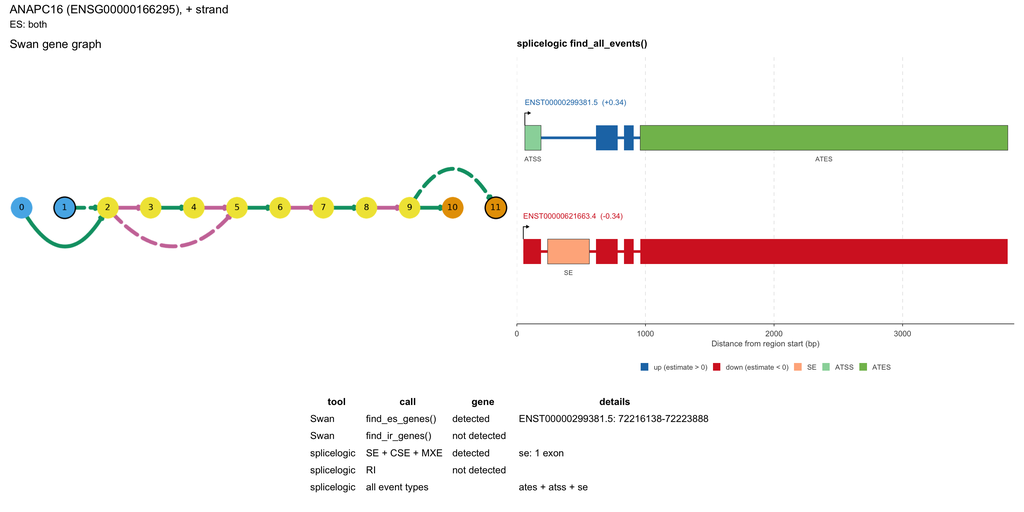

`sg.find_es_genes().query("gid == 'ENSG00000166295'")`

| gid | tid | edge_id |
| --- | --- | --- |
| ENSG00000166295 | ENST00000299381.5 | 11232 |

`sg.find_ir_genes().query("gid == 'ENSG00000166295'")`

**0 rows**: the gene is not in this output

`find_all_events(sl_pre) |> filter(gene_id == "ENSG00000166295.9", event_type %in% c("se", "cse", "mxe"))`

| seqnames | start | end | strand | gene_id | tx_id | exon_rank | estimate | event_type | event_tx_id | event_estimate |
| --- | --- | --- | --- | --- | --- | --- | --- | --- | --- | --- |
| chr10 | 72220054 | 72220379 | + | ENSG00000166295.9 | ENST00000621663.4 | 2 | -0.344 | se | ENST00000299381.5 | 0.344 |

`find_all_events(sl_pre) |> filter(gene_id == "ENSG00000166295.9", event_type %in% c("ri"))`

**0 rows**: the gene is not in this output

`find_all_events(sl_pre) |> filter(gene_id == "ENSG00000166295.9", event_type %in% c("atss", "ates"))`

| seqnames | start | end | strand | gene_id | tx_id | exon_rank | estimate | event_type | event_tx_id | event_estimate |
| --- | --- | --- | --- | --- | --- | --- | --- | --- | --- | --- |
| chr10 | 72216012 | 72216138 | + | ENSG00000166295.9 | ENST00000299381.5 | 1 | 0.344 | atss | ENST00000621663.4 | -0.344 |
| chr10 | 72233001 | 72235860 | + | ENSG00000166295.9 | ENST00000299381.5 | 4 | 0.344 | ates | ENST00000621663.4 | -0.344 |

### Minus strand: splicelogic only

#### ABI1 (ENSG00000136754)

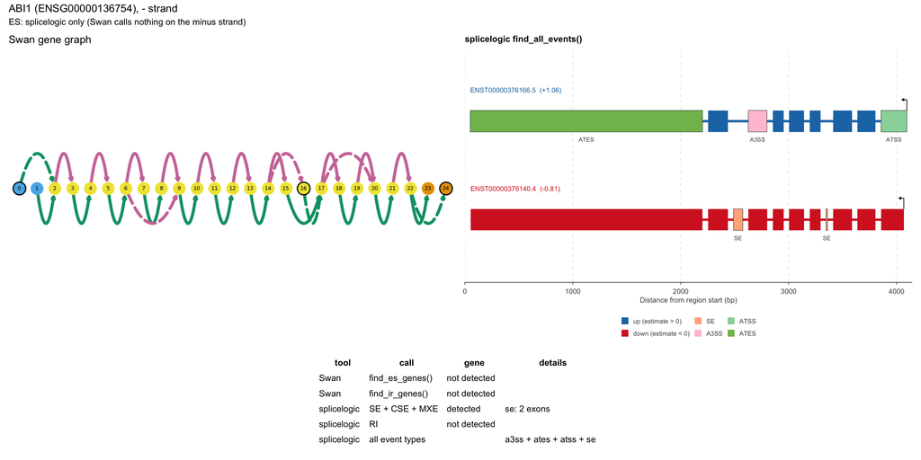

`sg.find_es_genes().query("gid == 'ENSG00000136754'")`

**0 rows**: the gene is not in this output

`sg.find_ir_genes().query("gid == 'ENSG00000136754'")`

**0 rows**: the gene is not in this output

`find_all_events(sl_pre) |> filter(gene_id == "ENSG00000136754.18", event_type %in% c("se", "cse", "mxe"))`

| seqnames | start | end | strand | gene_id | tx_id | exon_rank | estimate | event_type | event_tx_id | event_estimate |
| --- | --- | --- | --- | --- | --- | --- | --- | --- | --- | --- |
| chr10 | 26771075 | 26771089 | - | ENSG00000136754.18 | ENST00000376140.4 | 4 | -0.807 | se | ENST00000376166.5 | 1.056 |
| chr10 | 26755655 | 26755741 | - | ENSG00000136754.18 | ENST00000376140.4 | 9 | -0.807 | se | ENST00000376166.5 | 1.056 |

`find_all_events(sl_pre) |> filter(gene_id == "ENSG00000136754.18", event_type %in% c("ri"))`

**0 rows**: the gene is not in this output

`find_all_events(sl_pre) |> filter(gene_id == "ENSG00000136754.18", event_type %in% c("atss", "ates"))`

| seqnames | start | end | strand | gene_id | tx_id | exon_rank | estimate | event_type | event_tx_id | event_estimate |
| --- | --- | --- | --- | --- | --- | --- | --- | --- | --- | --- |
| chr10 | 26860747 | 26860986 | - | ENSG00000136754.18 | ENST00000376166.5 | 1 | 1.056 | atss | ENST00000376140.4 | -0.807 |
| chr10 | 26746593 | 26748745 | - | ENSG00000136754.18 | ENST00000376166.5 | 9 | 1.056 | ates | ENST00000376140.4 | -0.807 |

### Plus strand, splicelogic only: skipping intron also in a down transcript

#### CALD1 (ENSG00000122786)

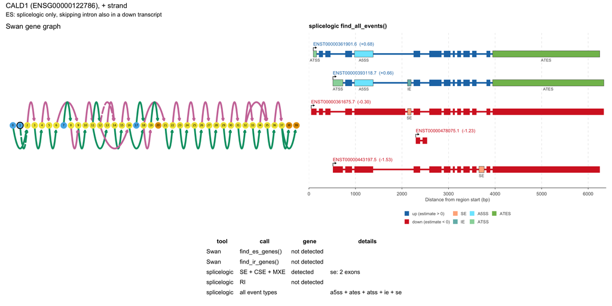

`sg.find_es_genes().query("gid == 'ENSG00000122786'")`

**0 rows**: the gene is not in this output

`sg.find_ir_genes().query("gid == 'ENSG00000122786'")`

**0 rows**: the gene is not in this output

`find_all_events(sl_pre) |> filter(gene_id == "ENSG00000122786.20", event_type %in% c("se", "cse", "mxe"))`

| seqnames | start | end | strand | gene_id | tx_id | exon_rank | estimate | event_type | event_tx_id | event_estimate |
| --- | --- | --- | --- | --- | --- | --- | --- | --- | --- | --- |
| chr7 | 134935688 | 134935765 | + | ENSG00000122786.20 | ENST00000361675.7 | 6 | -0.296 | se | ENST00000361901.6 | 0.680 |
| chr7 | 134962820 | 134962934 | + | ENSG00000122786.20 | ENST00000443197.5 | 11 | -1.534 | se | ENST00000361901.6 | 0.680 |
| chr7 | 134962820 | 134962934 | + | ENSG00000122786.20 | ENST00000443197.5 | 11 | -1.534 | se | ENST00000393118.7 | 0.662 |

`find_all_events(sl_pre) |> filter(gene_id == "ENSG00000122786.20", event_type %in% c("ri"))`

**0 rows**: the gene is not in this output

`find_all_events(sl_pre) |> filter(gene_id == "ENSG00000122786.20", event_type %in% c("atss", "ates"))`

| seqnames | start | end | strand | gene_id | tx_id | exon_rank | estimate | event_type | event_tx_id | event_estimate |
| --- | --- | --- | --- | --- | --- | --- | --- | --- | --- | --- |
| chr7 | 134779678 | 134779749 | + | ENSG00000122786.20 | ENST00000361901.6 | 1 | 0.680 | atss | ENST00000361675.7 | -0.296 |
| chr7 | 134779678 | 134779749 | + | ENSG00000122786.20 | ENST00000361901.6 | 1 | 0.680 | atss | ENST00000443197.5 | -1.534 |
| chr7 | 134779678 | 134779749 | + | ENSG00000122786.20 | ENST00000361901.6 | 1 | 0.680 | atss | ENST00000478075.1 | -1.232 |
| chr7 | 134891458 | 134891673 | + | ENSG00000122786.20 | ENST00000393118.7 | 1 | 0.662 | atss | ENST00000361675.7 | -0.296 |
| chr7 | 134891458 | 134891673 | + | ENSG00000122786.20 | ENST00000393118.7 | 1 | 0.662 | atss | ENST00000478075.1 | -1.232 |
| chr7 | 134968340 | 134970641 | + | ENSG00000122786.20 | ENST00000361901.6 | 14 | 0.680 | ates | ENST00000361675.7 | -0.296 |
| chr7 | 134968340 | 134970641 | + | ENSG00000122786.20 | ENST00000361901.6 | 14 | 0.680 | ates | ENST00000478075.1 | -1.232 |
| chr7 | 134968340 | 134970729 | + | ENSG00000122786.20 | ENST00000393118.7 | 13 | 0.662 | ates | ENST00000443197.5 | -1.534 |
| chr7 | 134968340 | 134970729 | + | ENSG00000122786.20 | ENST00000393118.7 | 13 | 0.662 | ates | ENST00000478075.1 | -1.232 |

#### CALU (ENSG00000128595)

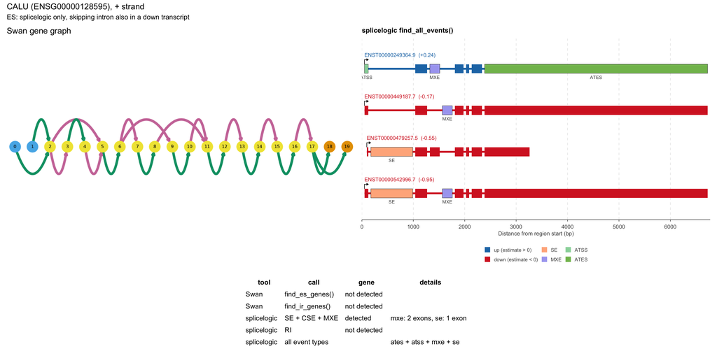

`sg.find_es_genes().query("gid == 'ENSG00000128595'")`

**0 rows**: the gene is not in this output

`sg.find_ir_genes().query("gid == 'ENSG00000128595'")`

**0 rows**: the gene is not in this output

`find_all_events(sl_pre) |> filter(gene_id == "ENSG00000128595.17", event_type %in% c("se", "cse", "mxe"))`

| seqnames | start | end | strand | gene_id | tx_id | exon_rank | estimate | event_type | event_tx_id | event_estimate |
| --- | --- | --- | --- | --- | --- | --- | --- | --- | --- | --- |
| chr7 | 128747553 | 128748367 | + | ENSG00000128595.17 | ENST00000542996.7 | 2 | -0.951 | se | ENST00000249364.9 | 0.244 |
| chr7 | 128747553 | 128748367 | + | ENSG00000128595.17 | ENST00000479257.5 | 2 | -0.551 | se | ENST00000249364.9 | 0.244 |
| chr7 | 128754529 | 128754722 | + | ENSG00000128595.17 | ENST00000449187.7 | 3 | -0.173 | mxe | ENST00000249364.9 | 0.244 |
| chr7 | 128754262 | 128754455 | + | ENSG00000128595.17 | ENST00000249364.9 | 3 | 0.244 | mxe | ENST00000449187.7 | -0.173 |
| chr7 | 128754529 | 128754722 | + | ENSG00000128595.17 | ENST00000542996.7 | 4 | -0.951 | mxe | ENST00000249364.9 | 0.244 |
| chr7 | 128754262 | 128754455 | + | ENSG00000128595.17 | ENST00000249364.9 | 3 | 0.244 | mxe | ENST00000542996.7 | -0.951 |

`find_all_events(sl_pre) |> filter(gene_id == "ENSG00000128595.17", event_type %in% c("ri"))`

**0 rows**: the gene is not in this output

`find_all_events(sl_pre) |> filter(gene_id == "ENSG00000128595.17", event_type %in% c("atss", "ates"))`

| seqnames | start | end | strand | gene_id | tx_id | exon_rank | estimate | event_type | event_tx_id | event_estimate |
| --- | --- | --- | --- | --- | --- | --- | --- | --- | --- | --- |
| chr7 | 128739359 | 128739432 | + | ENSG00000128595.17 | ENST00000249364.9 | 1 | 0.244 | atss | ENST00000479257.5 | -0.551 |
| chr7 | 128769063 | 128773400 | + | ENSG00000128595.17 | ENST00000249364.9 | 7 | 0.244 | ates | ENST00000479257.5 | -0.551 |

#### CD46 (ENSG00000117335)

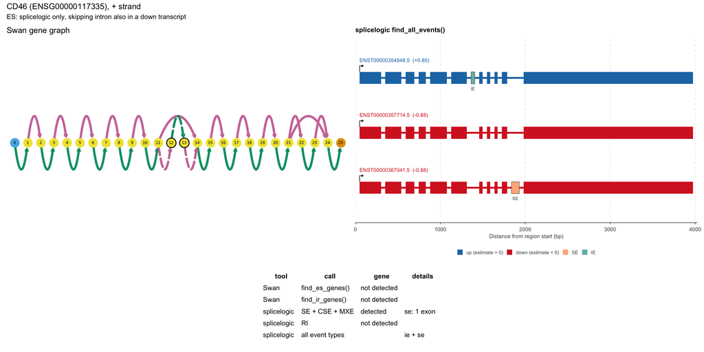

`sg.find_es_genes().query("gid == 'ENSG00000117335'")`

**0 rows**: the gene is not in this output

`sg.find_ir_genes().query("gid == 'ENSG00000117335'")`

**0 rows**: the gene is not in this output

`find_all_events(sl_pre) |> filter(gene_id == "ENSG00000117335.21", event_type %in% c("se", "cse", "mxe"))`

| seqnames | start | end | strand | gene_id | tx_id | exon_rank | estimate | event_type | event_tx_id | event_estimate |
| --- | --- | --- | --- | --- | --- | --- | --- | --- | --- | --- |
| chr1 | 207790253 | 207790345 | + | ENSG00000117335.21 | ENST00000367041.5 | 11 | -0.883 | se | ENST00000354848.5 | 0.853 |

`find_all_events(sl_pre) |> filter(gene_id == "ENSG00000117335.21", event_type %in% c("ri"))`

**0 rows**: the gene is not in this output

`find_all_events(sl_pre) |> filter(gene_id == "ENSG00000117335.21", event_type %in% c("atss", "ates"))`

**0 rows**: the gene is not in this output

#### FXR1 (ENSG00000114416)

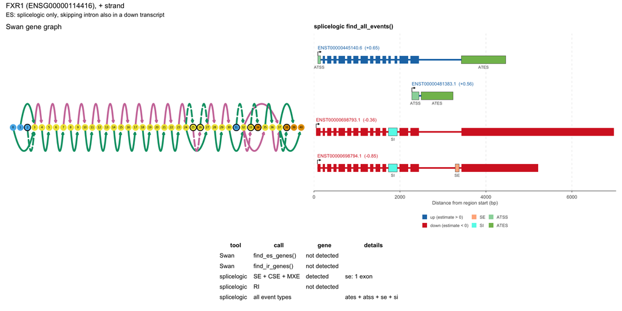

`sg.find_es_genes().query("gid == 'ENSG00000114416'")`

**0 rows**: the gene is not in this output

`sg.find_ir_genes().query("gid == 'ENSG00000114416'")`

**0 rows**: the gene is not in this output

`find_all_events(sl_pre) |> filter(gene_id == "ENSG00000114416.19", event_type %in% c("se", "cse", "mxe"))`

| seqnames | start | end | strand | gene_id | tx_id | exon_rank | estimate | event_type | event_tx_id | event_estimate |
| --- | --- | --- | --- | --- | --- | --- | --- | --- | --- | --- |
| chr3 | 180975313 | 180975404 | + | ENSG00000114416.19 | ENST00000698794.1 | 15 | -0.851 | se | ENST00000445140.6 | 0.652 |

`find_all_events(sl_pre) |> filter(gene_id == "ENSG00000114416.19", event_type %in% c("ri"))`

**0 rows**: the gene is not in this output

`find_all_events(sl_pre) |> filter(gene_id == "ENSG00000114416.19", event_type %in% c("atss", "ates"))`

| seqnames | start | end | strand | gene_id | tx_id | exon_rank | estimate | event_type | event_tx_id | event_estimate |
| --- | --- | --- | --- | --- | --- | --- | --- | --- | --- | --- |
| chr3 | 180912672 | 180912736 | + | ENSG00000114416.19 | ENST00000445140.6 | 1 | 0.652 | atss | ENST00000698793.1 | -0.365 |
| chr3 | 180912672 | 180912736 | + | ENSG00000114416.19 | ENST00000445140.6 | 1 | 0.652 | atss | ENST00000698794.1 | -0.851 |
| chr3 | 180970192 | 180970358 | + | ENSG00000114416.19 | ENST00000481383.1 | 1 | 0.558 | atss | ENST00000698793.1 | -0.365 |
| chr3 | 180970192 | 180970358 | + | ENSG00000114416.19 | ENST00000481383.1 | 1 | 0.558 | atss | ENST00000698794.1 | -0.851 |
| chr3 | 180976122 | 180977155 | + | ENSG00000114416.19 | ENST00000445140.6 | 16 | 0.652 | ates | ENST00000698793.1 | -0.365 |
| chr3 | 180976122 | 180977155 | + | ENSG00000114416.19 | ENST00000445140.6 | 16 | 0.652 | ates | ENST00000698794.1 | -0.851 |
| chr3 | 180971075 | 180971816 | + | ENSG00000114416.19 | ENST00000481383.1 | 2 | 0.558 | ates | ENST00000698793.1 | -0.365 |
| chr3 | 180971075 | 180971816 | + | ENSG00000114416.19 | ENST00000481383.1 | 2 | 0.558 | ates | ENST00000698794.1 | -0.851 |

#### HNRNPA1 (ENSG00000135486)

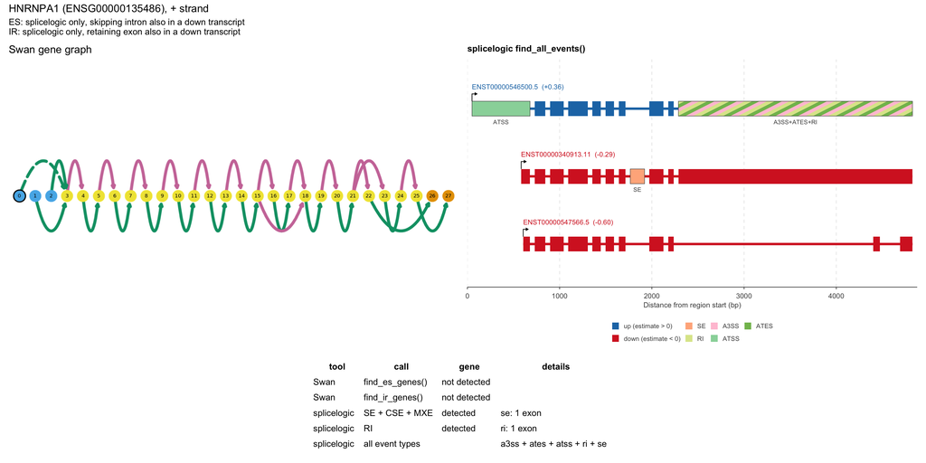

`sg.find_es_genes().query("gid == 'ENSG00000135486'")`

**0 rows**: the gene is not in this output

`sg.find_ir_genes().query("gid == 'ENSG00000135486'")`

**0 rows**: the gene is not in this output

`find_all_events(sl_pre) |> filter(gene_id == "ENSG00000135486.19", event_type %in% c("se", "cse", "mxe"))`

| seqnames | start | end | strand | gene_id | tx_id | exon_rank | estimate | event_type | event_tx_id | event_estimate |
| --- | --- | --- | --- | --- | --- | --- | --- | --- | --- | --- |
| chr12 | 54283079 | 54283234 | + | ENSG00000135486.19 | ENST00000340913.11 | 8 | -0.294 | se | ENST00000546500.5 | 0.359 |

`find_all_events(sl_pre) |> filter(gene_id == "ENSG00000135486.19", event_type %in% c("ri"))`

| seqnames | start | end | strand | gene_id | tx_id | exon_rank | estimate | event_type | event_tx_id | event_estimate |
| --- | --- | --- | --- | --- | --- | --- | --- | --- | --- | --- |
| chr12 | 54284549 | 54287087 | + | ENSG00000135486.19 | ENST00000546500.5 | 10 | 0.359 | ri | ENST00000547566.5 | -0.605 |

`find_all_events(sl_pre) |> filter(gene_id == "ENSG00000135486.19", event_type %in% c("atss", "ates"))`

| seqnames | start | end | strand | gene_id | tx_id | exon_rank | estimate | event_type | event_tx_id | event_estimate |
| --- | --- | --- | --- | --- | --- | --- | --- | --- | --- | --- |
| chr12 | 54280193 | 54280822 | + | ENSG00000135486.19 | ENST00000546500.5 | 1 | 0.359 | atss | ENST00000340913.11 | -0.294 |
| chr12 | 54280193 | 54280822 | + | ENSG00000135486.19 | ENST00000546500.5 | 1 | 0.359 | atss | ENST00000547566.5 | -0.605 |
| chr12 | 54284549 | 54287087 | + | ENSG00000135486.19 | ENST00000546500.5 | 10 | 0.359 | ates | ENST00000547566.5 | -0.605 |

#### MEG3 (ENSG00000214548)

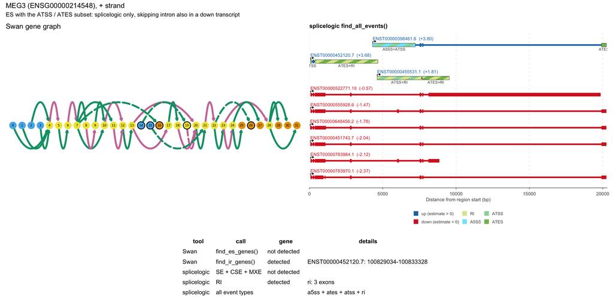

`sg.find_es_genes().query("gid == 'ENSG00000214548'")`

**0 rows**: the gene is not in this output

`sg.find_ir_genes().query("gid == 'ENSG00000214548'")`

| gid | tid | edge_id |
| --- | --- | --- |
| ENSG00000214548 | ENST00000452120.7 | 12437 |
| ENSG00000214548 | ENST00000452120.7 | 12437 |
| ENSG00000214548 | ENST00000452120.7 | 12437 |

`find_all_events(sl_pre) |> filter(gene_id == "ENSG00000214548.20", event_type %in% c("se", "cse", "mxe"))`

**0 rows**: the gene is not in this output

`find_all_events(sl_pre) |> filter(gene_id == "ENSG00000214548.20", event_type %in% c("ri"))`

| seqnames | start | end | strand | gene_id | tx_id | exon_rank | estimate | event_type | event_tx_id | event_estimate |
| --- | --- | --- | --- | --- | --- | --- | --- | --- | --- | --- |
| chr14 | 100829034 | 100833328 | + | ENSG00000214548.20 | ENST00000452120.7 | 3 | 3.677 | ri | ENST00000451743.7 | -2.043 |
| chr14 | 100829034 | 100833328 | + | ENSG00000214548.20 | ENST00000452120.7 | 3 | 3.677 | ri | ENST00000522771.10 | -0.569 |
| chr14 | 100845458 | 100847301 | + | ENSG00000214548.20 | ENST00000455531.1 | 2 | 1.809 | ri | ENST00000522771.10 | -0.569 |
| chr14 | 100829034 | 100833328 | + | ENSG00000214548.20 | ENST00000452120.7 | 3 | 3.677 | ri | ENST00000555928.6 | -1.471 |
| chr14 | 100833278 | 100836300 | + | ENSG00000214548.20 | ENST00000455531.1 | 1 | 1.809 | ri | ENST00000555928.6 | -1.471 |
| chr14 | 100829034 | 100833328 | + | ENSG00000214548.20 | ENST00000452120.7 | 3 | 3.677 | ri | ENST00000648456.2 | -1.783 |
| chr14 | 100829034 | 100833328 | + | ENSG00000214548.20 | ENST00000452120.7 | 3 | 3.677 | ri | ENST00000783970.1 | -2.372 |
| chr14 | 100829034 | 100833328 | + | ENSG00000214548.20 | ENST00000452120.7 | 3 | 3.677 | ri | ENST00000783984.1 | -2.118 |
| chr14 | 100833278 | 100836300 | + | ENSG00000214548.20 | ENST00000455531.1 | 1 | 1.809 | ri | ENST00000783984.1 | -2.118 |
| chr14 | 100845458 | 100847301 | + | ENSG00000214548.20 | ENST00000455531.1 | 2 | 1.809 | ri | ENST00000783984.1 | -2.118 |

`find_all_events(sl_pre) |> filter(gene_id == "ENSG00000214548.20", event_type %in% c("atss", "ates"))`

| seqnames | start | end | strand | gene_id | tx_id | exon_rank | estimate | event_type | event_tx_id | event_estimate |
| --- | --- | --- | --- | --- | --- | --- | --- | --- | --- | --- |
| chr14 | 100826118 | 100826217 | + | ENSG00000214548.20 | ENST00000452120.7 | 1 | 3.677 | atss | ENST00000648456.2 | -1.783 |
| chr14 | 100826118 | 100826217 | + | ENSG00000214548.20 | ENST00000452120.7 | 1 | 3.677 | atss | ENST00000451743.7 | -2.043 |
| chr14 | 100826118 | 100826217 | + | ENSG00000214548.20 | ENST00000452120.7 | 1 | 3.677 | atss | ENST00000522771.10 | -0.569 |
| chr14 | 100826118 | 100826217 | + | ENSG00000214548.20 | ENST00000452120.7 | 1 | 3.677 | atss | ENST00000555928.6 | -1.471 |
| chr14 | 100832969 | 100835879 | + | ENSG00000214548.20 | ENST00000398461.6 | 1 | 3.801 | atss | ENST00000648456.2 | -1.783 |
| chr14 | 100832969 | 100835879 | + | ENSG00000214548.20 | ENST00000398461.6 | 1 | 3.801 | atss | ENST00000451743.7 | -2.043 |
| chr14 | 100832969 | 100835879 | + | ENSG00000214548.20 | ENST00000398461.6 | 1 | 3.801 | atss | ENST00000522771.10 | -0.569 |
| chr14 | 100832969 | 100835879 | + | ENSG00000214548.20 | ENST00000398461.6 | 1 | 3.801 | atss | ENST00000555928.6 | -1.471 |
| chr14 | 100832969 | 100835879 | + | ENSG00000214548.20 | ENST00000398461.6 | 1 | 3.801 | atss | ENST00000783984.1 | -2.118 |
| chr14 | 100832969 | 100835879 | + | ENSG00000214548.20 | ENST00000398461.6 | 1 | 3.801 | atss | ENST00000783970.1 | -2.372 |
| chr14 | 100833278 | 100836300 | + | ENSG00000214548.20 | ENST00000455531.1 | 1 | 1.809 | atss | ENST00000648456.2 | -1.783 |
| chr14 | 100833278 | 100836300 | + | ENSG00000214548.20 | ENST00000455531.1 | 1 | 1.809 | atss | ENST00000451743.7 | -2.043 |
| chr14 | 100833278 | 100836300 | + | ENSG00000214548.20 | ENST00000455531.1 | 1 | 1.809 | atss | ENST00000522771.10 | -0.569 |
| chr14 | 100833278 | 100836300 | + | ENSG00000214548.20 | ENST00000455531.1 | 1 | 1.809 | atss | ENST00000555928.6 | -1.471 |
| chr14 | 100833278 | 100836300 | + | ENSG00000214548.20 | ENST00000455531.1 | 1 | 1.809 | atss | ENST00000783984.1 | -2.118 |
| chr14 | 100833278 | 100836300 | + | ENSG00000214548.20 | ENST00000455531.1 | 1 | 1.809 | atss | ENST00000783970.1 | -2.372 |
| chr14 | 100829034 | 100833328 | + | ENSG00000214548.20 | ENST00000452120.7 | 3 | 3.677 | ates | ENST00000648456.2 | -1.783 |
| chr14 | 100829034 | 100833328 | + | ENSG00000214548.20 | ENST00000452120.7 | 3 | 3.677 | ates | ENST00000451743.7 | -2.043 |
| chr14 | 100829034 | 100833328 | + | ENSG00000214548.20 | ENST00000452120.7 | 3 | 3.677 | ates | ENST00000522771.10 | -0.569 |
| chr14 | 100829034 | 100833328 | + | ENSG00000214548.20 | ENST00000452120.7 | 3 | 3.677 | ates | ENST00000555928.6 | -1.471 |
| chr14 | 100829034 | 100833328 | + | ENSG00000214548.20 | ENST00000452120.7 | 3 | 3.677 | ates | ENST00000783984.1 | -2.118 |
| chr14 | 100829034 | 100833328 | + | ENSG00000214548.20 | ENST00000452120.7 | 3 | 3.677 | ates | ENST00000783970.1 | -2.372 |
| chr14 | 100860691 | 100861026 | + | ENSG00000214548.20 | ENST00000398461.6 | 4 | 3.801 | ates | ENST00000648456.2 | -1.783 |
| chr14 | 100860691 | 100861026 | + | ENSG00000214548.20 | ENST00000398461.6 | 4 | 3.801 | ates | ENST00000451743.7 | -2.043 |
| chr14 | 100860691 | 100861026 | + | ENSG00000214548.20 | ENST00000398461.6 | 4 | 3.801 | ates | ENST00000522771.10 | -0.569 |
| chr14 | 100860691 | 100861026 | + | ENSG00000214548.20 | ENST00000398461.6 | 4 | 3.801 | ates | ENST00000783984.1 | -2.118 |
| chr14 | 100845458 | 100847301 | + | ENSG00000214548.20 | ENST00000455531.1 | 2 | 1.809 | ates | ENST00000648456.2 | -1.783 |
| chr14 | 100845458 | 100847301 | + | ENSG00000214548.20 | ENST00000455531.1 | 2 | 1.809 | ates | ENST00000451743.7 | -2.043 |
| chr14 | 100845458 | 100847301 | + | ENSG00000214548.20 | ENST00000455531.1 | 2 | 1.809 | ates | ENST00000522771.10 | -0.569 |
| chr14 | 100845458 | 100847301 | + | ENSG00000214548.20 | ENST00000455531.1 | 2 | 1.809 | ates | ENST00000555928.6 | -1.471 |
| chr14 | 100845458 | 100847301 | + | ENSG00000214548.20 | ENST00000455531.1 | 2 | 1.809 | ates | ENST00000783984.1 | -2.118 |
| chr14 | 100845458 | 100847301 | + | ENSG00000214548.20 | ENST00000455531.1 | 2 | 1.809 | ates | ENST00000783970.1 | -2.372 |

#### SPTAN1 (ENSG00000197694)

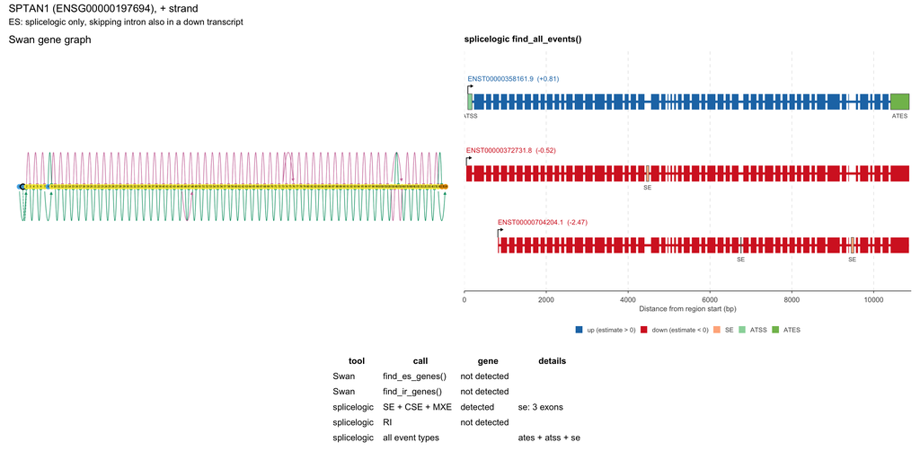

`sg.find_es_genes().query("gid == 'ENSG00000197694'")`

**0 rows**: the gene is not in this output

`sg.find_ir_genes().query("gid == 'ENSG00000197694'")`

**0 rows**: the gene is not in this output

`find_all_events(sl_pre) |> filter(gene_id == "ENSG00000197694.19", event_type %in% c("se", "cse", "mxe"))`

| seqnames | start | end | strand | gene_id | tx_id | exon_rank | estimate | event_type | event_tx_id | event_estimate |
| --- | --- | --- | --- | --- | --- | --- | --- | --- | --- | --- |
| chr9 | 128592983 | 128593042 | + | ENSG00000197694.19 | ENST00000372731.8 | 23 | -0.516 | se | ENST00000358161.9 | 0.811 |
| chr9 | 128609651 | 128609665 | + | ENSG00000197694.19 | ENST00000704204.1 | 33 | -2.475 | se | ENST00000358161.9 | 0.811 |
| chr9 | 128629125 | 128629187 | + | ENSG00000197694.19 | ENST00000704204.1 | 48 | -2.475 | se | ENST00000358161.9 | 0.811 |

`find_all_events(sl_pre) |> filter(gene_id == "ENSG00000197694.19", event_type %in% c("ri"))`

**0 rows**: the gene is not in this output

`find_all_events(sl_pre) |> filter(gene_id == "ENSG00000197694.19", event_type %in% c("atss", "ates"))`

| seqnames | start | end | strand | gene_id | tx_id | exon_rank | estimate | event_type | event_tx_id | event_estimate |
| --- | --- | --- | --- | --- | --- | --- | --- | --- | --- | --- |
| chr9 | 128552593 | 128552696 | + | ENSG00000197694.19 | ENST00000358161.9 | 1 | 0.811 | atss | ENST00000372731.8 | -0.516 |
| chr9 | 128552593 | 128552696 | + | ENSG00000197694.19 | ENST00000358161.9 | 1 | 0.811 | atss | ENST00000704204.1 | -2.475 |
| chr9 | 128633209 | 128633662 | + | ENSG00000197694.19 | ENST00000358161.9 | 55 | 0.811 | ates | ENST00000704204.1 | -2.475 |

### Plus strand, Swan only: exon inside only in up transcripts

#### CD44 (ENSG00000026508)

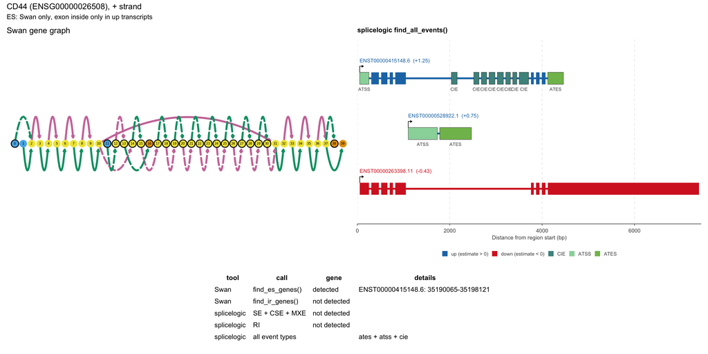

`sg.find_es_genes().query("gid == 'ENSG00000026508'")`

| gid | tid | edge_id |
| --- | --- | --- |
| ENSG00000026508 | ENST00000415148.6 | 12291 |

`sg.find_ir_genes().query("gid == 'ENSG00000026508'")`

**0 rows**: the gene is not in this output

`find_all_events(sl_pre) |> filter(gene_id == "ENSG00000026508.21", event_type %in% c("se", "cse", "mxe"))`

**0 rows**: the gene is not in this output

`find_all_events(sl_pre) |> filter(gene_id == "ENSG00000026508.21", event_type %in% c("ri"))`

**0 rows**: the gene is not in this output

`find_all_events(sl_pre) |> filter(gene_id == "ENSG00000026508.21", event_type %in% c("atss", "ates"))`

| seqnames | start | end | strand | gene_id | tx_id | exon_rank | estimate | event_type | event_tx_id | event_estimate |
| --- | --- | --- | --- | --- | --- | --- | --- | --- | --- | --- |
| chr11 | 35139170 | 35139370 | + | ENSG00000026508.21 | ENST00000415148.6 | 1 | 1.248 | atss | ENST00000263398.11 | -0.433 |
| chr11 | 35197162 | 35197793 | + | ENSG00000026508.21 | ENST00000528922.1 | 1 | 0.753 | atss | ENST00000263398.11 | -0.433 |
| chr11 | 35229129 | 35229468 | + | ENSG00000026508.21 | ENST00000415148.6 | 17 | 1.248 | ates | ENST00000263398.11 | -0.433 |
| chr11 | 35197869 | 35198555 | + | ENSG00000026508.21 | ENST00000528922.1 | 2 | 0.753 | ates | ENST00000263398.11 | -0.433 |

#### COL8A1 (ENSG00000144810)

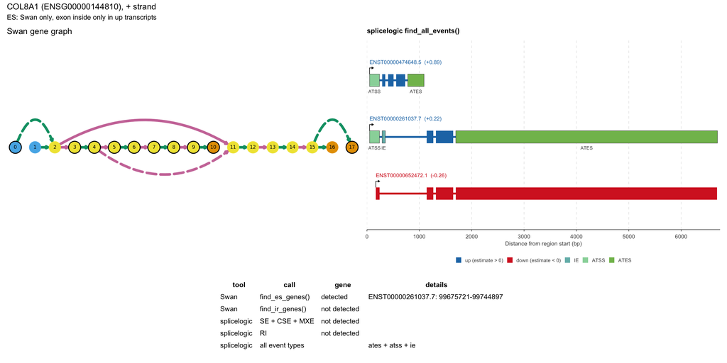

`sg.find_es_genes().query("gid == 'ENSG00000144810'")`

| gid | tid | edge_id |
| --- | --- | --- |
| ENSG00000144810 | ENST00000261037.7 | 10974 |
| ENSG00000144810 | ENST00000261037.7 | 10974 |
| ENSG00000144810 | ENST00000261037.7 | 10974 |

`sg.find_ir_genes().query("gid == 'ENSG00000144810'")`

**0 rows**: the gene is not in this output

`find_all_events(sl_pre) |> filter(gene_id == "ENSG00000144810.16", event_type %in% c("se", "cse", "mxe"))`

**0 rows**: the gene is not in this output

`find_all_events(sl_pre) |> filter(gene_id == "ENSG00000144810.16", event_type %in% c("ri"))`

**0 rows**: the gene is not in this output

`find_all_events(sl_pre) |> filter(gene_id == "ENSG00000144810.16", event_type %in% c("atss", "ates"))`

| seqnames | start | end | strand | gene_id | tx_id | exon_rank | estimate | event_type | event_tx_id | event_estimate |
| --- | --- | --- | --- | --- | --- | --- | --- | --- | --- | --- |
| chr3 | 99638475 | 99638664 | + | ENSG00000144810.16 | ENST00000474648.5 | 1 | 0.892 | atss | ENST00000652472.1 | -0.265 |
| chr3 | 99638475 | 99638664 | + | ENSG00000144810.16 | ENST00000261037.7 | 1 | 0.217 | atss | ENST00000652472.1 | -0.265 |
| chr3 | 99703307 | 99703618 | + | ENSG00000144810.16 | ENST00000474648.5 | 5 | 0.892 | ates | ENST00000652472.1 | -0.265 |
| chr3 | 99794230 | 99799226 | + | ENSG00000144810.16 | ENST00000261037.7 | 5 | 0.217 | ates | ENST00000652472.1 | -0.265 |

#### IFI44 (ENSG00000137965)

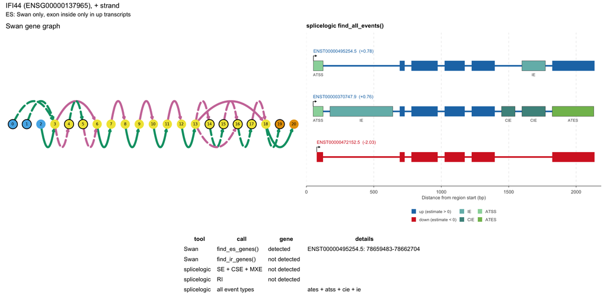

`sg.find_es_genes().query("gid == 'ENSG00000137965'")`

| gid | tid | edge_id |
| --- | --- | --- |
| ENSG00000137965 | ENST00000495254.5 | 12587 |

`sg.find_ir_genes().query("gid == 'ENSG00000137965'")`

**0 rows**: the gene is not in this output

`find_all_events(sl_pre) |> filter(gene_id == "ENSG00000137965.11", event_type %in% c("se", "cse", "mxe"))`

**0 rows**: the gene is not in this output

`find_all_events(sl_pre) |> filter(gene_id == "ENSG00000137965.11", event_type %in% c("ri"))`

**0 rows**: the gene is not in this output

`find_all_events(sl_pre) |> filter(gene_id == "ENSG00000137965.11", event_type %in% c("atss", "ates"))`

| seqnames | start | end | strand | gene_id | tx_id | exon_rank | estimate | event_type | event_tx_id | event_estimate |
| --- | --- | --- | --- | --- | --- | --- | --- | --- | --- | --- |
| chr1 | 78649831 | 78649905 | + | ENSG00000137965.11 | ENST00000370747.9 | 1 | 0.760 | atss | ENST00000472152.5 | -2.032 |
| chr1 | 78649833 | 78649905 | + | ENSG00000137965.11 | ENST00000495254.5 | 1 | 0.782 | atss | ENST00000472152.5 | -2.032 |
| chr1 | 78663765 | 78664073 | + | ENSG00000137965.11 | ENST00000370747.9 | 9 | 0.760 | ates | ENST00000472152.5 | -2.032 |

### Plus strand, Swan only: down transcript’s first exon: alternative first exon

#### ALDOA (ENSG00000149925)

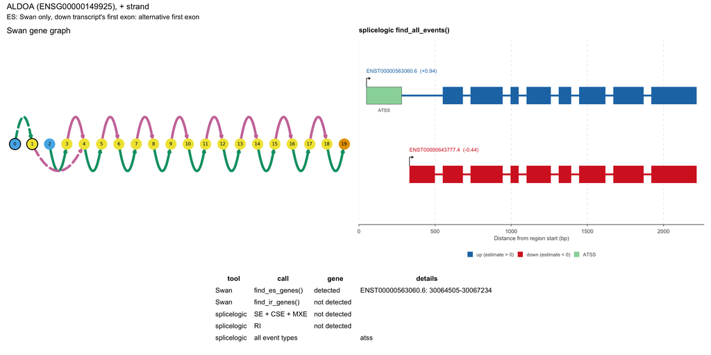

`sg.find_es_genes().query("gid == 'ENSG00000149925'")`

| gid | tid | edge_id |
| --- | --- | --- |
| ENSG00000149925 | ENST00000563060.6 | 12968 |

`sg.find_ir_genes().query("gid == 'ENSG00000149925'")`

**0 rows**: the gene is not in this output

`find_all_events(sl_pre) |> filter(gene_id == "ENSG00000149925.22", event_type %in% c("se", "cse", "mxe"))`

**0 rows**: the gene is not in this output

`find_all_events(sl_pre) |> filter(gene_id == "ENSG00000149925.22", event_type %in% c("ri"))`

**0 rows**: the gene is not in this output

`find_all_events(sl_pre) |> filter(gene_id == "ENSG00000149925.22", event_type %in% c("atss", "ates"))`

| seqnames | start | end | strand | gene_id | tx_id | exon_rank | estimate | event_type | event_tx_id | event_estimate |
| --- | --- | --- | --- | --- | --- | --- | --- | --- | --- | --- |
| chr16 | 30064274 | 30064505 | + | ENSG00000149925.22 | ENST00000563060.6 | 1 | 0.936 | atss | ENST00000643777.4 | -0.437 |

#### CAPN2 (ENSG00000162909)

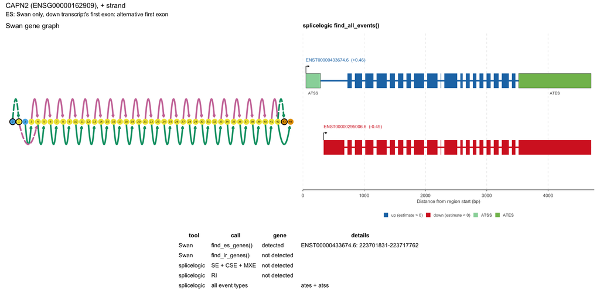

`sg.find_es_genes().query("gid == 'ENSG00000162909'")`

| gid | tid | edge_id |
| --- | --- | --- |
| ENSG00000162909 | ENST00000433674.6 | 12364 |

`sg.find_ir_genes().query("gid == 'ENSG00000162909'")`

**0 rows**: the gene is not in this output

`find_all_events(sl_pre) |> filter(gene_id == "ENSG00000162909.18", event_type %in% c("se", "cse", "mxe"))`

**0 rows**: the gene is not in this output

`find_all_events(sl_pre) |> filter(gene_id == "ENSG00000162909.18", event_type %in% c("ri"))`

**0 rows**: the gene is not in this output

`find_all_events(sl_pre) |> filter(gene_id == "ENSG00000162909.18", event_type %in% c("atss", "ates"))`

| seqnames | start | end | strand | gene_id | tx_id | exon_rank | estimate | event_type | event_tx_id | event_estimate |
| --- | --- | --- | --- | --- | --- | --- | --- | --- | --- | --- |
| chr1 | 223701593 | 223701831 | + | ENSG00000162909.18 | ENST00000433674.6 | 1 | 0.456 | atss | ENST00000295006.6 | -0.49 |
| chr1 | 223774834 | 223776016 | + | ENSG00000162909.18 | ENST00000433674.6 | 21 | 0.456 | ates | ENST00000295006.6 | -0.49 |

#### CDKN1B (ENSG00000111276)

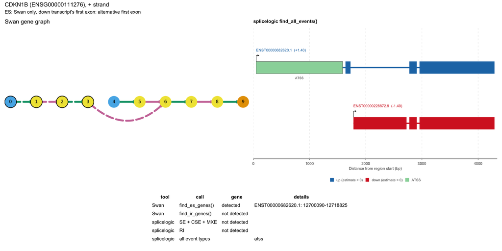

`sg.find_es_genes().query("gid == 'ENSG00000111276'")`

| gid | tid | edge_id |
| --- | --- | --- |
| ENSG00000111276 | ENST00000682620.1 | 13378 |

`sg.find_ir_genes().query("gid == 'ENSG00000111276'")`

**0 rows**: the gene is not in this output

`find_all_events(sl_pre) |> filter(gene_id == "ENSG00000111276.12", event_type %in% c("se", "cse", "mxe"))`

**0 rows**: the gene is not in this output

`find_all_events(sl_pre) |> filter(gene_id == "ENSG00000111276.12", event_type %in% c("ri"))`

**0 rows**: the gene is not in this output

`find_all_events(sl_pre) |> filter(gene_id == "ENSG00000111276.12", event_type %in% c("atss", "ates"))`

| seqnames | start | end | strand | gene_id | tx_id | exon_rank | estimate | event_type | event_tx_id | event_estimate |
| --- | --- | --- | --- | --- | --- | --- | --- | --- | --- | --- |
| chr12 | 12696359 | 12697897 | + | ENSG00000111276.12 | ENST00000682620.1 | 1 | 1.4 | atss | ENST00000228872.9 | -1.4 |

#### ENSG00000229647 (ENSG00000229647)

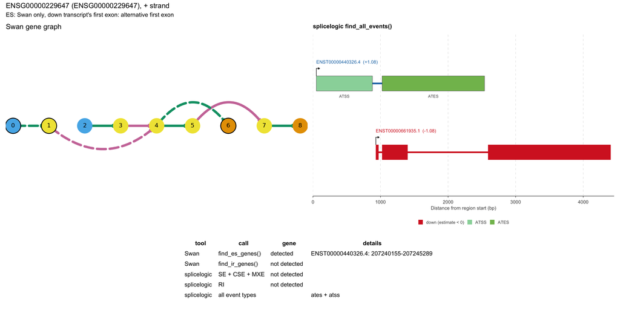

`sg.find_es_genes().query("gid == 'ENSG00000229647'")`

| gid | tid | edge_id |
| --- | --- | --- |
| ENSG00000229647 | ENST00000440326.4 | 12393 |

`sg.find_ir_genes().query("gid == 'ENSG00000229647'")`

**0 rows**: the gene is not in this output

`find_all_events(sl_pre) |> filter(gene_id == "ENSG00000229647.4", event_type %in% c("se", "cse", "mxe"))`

**0 rows**: the gene is not in this output

`find_all_events(sl_pre) |> filter(gene_id == "ENSG00000229647.4", event_type %in% c("ri"))`

**0 rows**: the gene is not in this output

`find_all_events(sl_pre) |> filter(gene_id == "ENSG00000229647.4", event_type %in% c("atss", "ates"))`

| seqnames | start | end | strand | gene_id | tx_id | exon_rank | estimate | event_type | event_tx_id | event_estimate |
| --- | --- | --- | --- | --- | --- | --- | --- | --- | --- | --- |
| chr2 | 207239325 | 207240155 | + | ENSG00000229647.4 | ENST00000440326.4 | 1 | 1.076 | atss | ENST00000661935.1 | -1.076 |
| chr2 | 207245289 | 207246804 | + | ENSG00000229647.4 | ENST00000440326.4 | 2 | 1.076 | ates | ENST00000661935.1 | -1.076 |

#### FUT8 (ENSG00000033170)

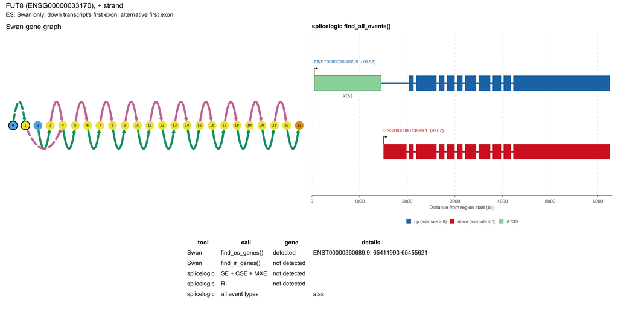

`sg.find_es_genes().query("gid == 'ENSG00000033170'")`

| gid | tid | edge_id |
| --- | --- | --- |
| ENSG00000033170 | ENST00000360689.9 | 11757 |

`sg.find_ir_genes().query("gid == 'ENSG00000033170'")`

**0 rows**: the gene is not in this output

`find_all_events(sl_pre) |> filter(gene_id == "ENSG00000033170.17", event_type %in% c("se", "cse", "mxe"))`

**0 rows**: the gene is not in this output

`find_all_events(sl_pre) |> filter(gene_id == "ENSG00000033170.17", event_type %in% c("ri"))`

**0 rows**: the gene is not in this output

`find_all_events(sl_pre) |> filter(gene_id == "ENSG00000033170.17", event_type %in% c("atss", "ates"))`

| seqnames | start | end | strand | gene_id | tx_id | exon_rank | estimate | event_type | event_tx_id | event_estimate |
| --- | --- | --- | --- | --- | --- | --- | --- | --- | --- | --- |
| chr14 | 65410592 | 65411993 | + | ENSG00000033170.17 | ENST00000360689.9 | 1 | 0.675 | atss | ENST00000673929.1 | -0.675 |

#### HIPK1 (ENSG00000163349)

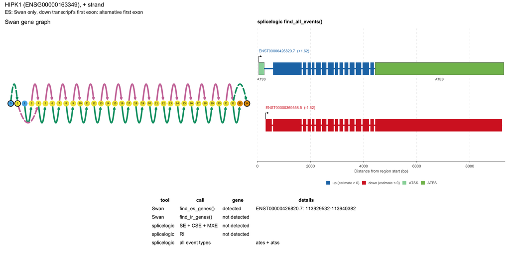

`sg.find_es_genes().query("gid == 'ENSG00000163349'")`

| gid | tid | edge_id |
| --- | --- | --- |
| ENSG00000163349 | ENST00000426820.7 | 12337 |

`sg.find_ir_genes().query("gid == 'ENSG00000163349'")`

**0 rows**: the gene is not in this output

`find_all_events(sl_pre) |> filter(gene_id == "ENSG00000163349.22", event_type %in% c("se", "cse", "mxe"))`

**0 rows**: the gene is not in this output

`find_all_events(sl_pre) |> filter(gene_id == "ENSG00000163349.22", event_type %in% c("ri"))`

**0 rows**: the gene is not in this output

`find_all_events(sl_pre) |> filter(gene_id == "ENSG00000163349.22", event_type %in% c("atss", "ates"))`

| seqnames | start | end | strand | gene_id | tx_id | exon_rank | estimate | event_type | event_tx_id | event_estimate |
| --- | --- | --- | --- | --- | --- | --- | --- | --- | --- | --- |
| chr1 | 113929324 | 113929532 | + | ENSG00000163349.22 | ENST00000426820.7 | 1 | 1.622 | atss | ENST00000369558.5 | -1.622 |
| chr1 | 113973024 | 113977869 | + | ENSG00000163349.22 | ENST00000426820.7 | 16 | 1.622 | ates | ENST00000369558.5 | -1.622 |

#### JDP2 (ENSG00000140044)

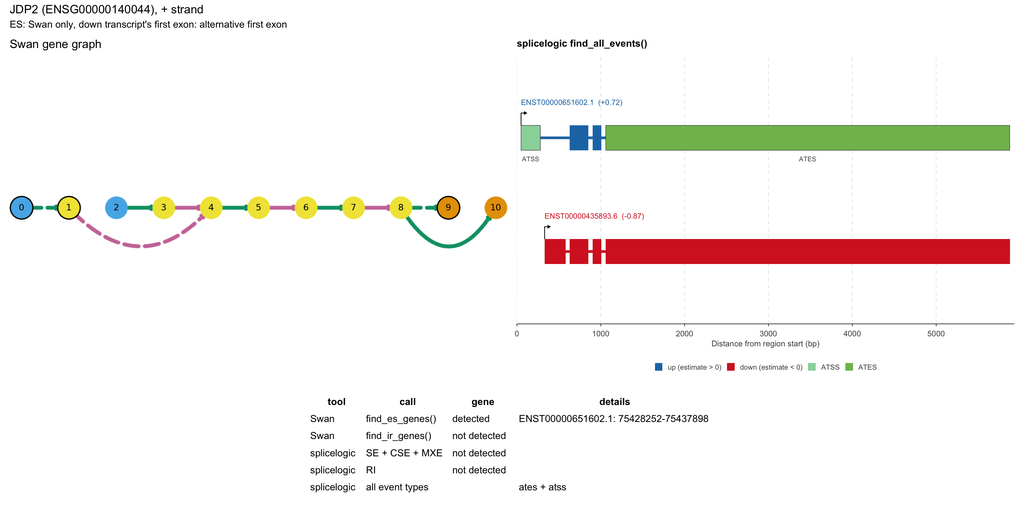

`sg.find_es_genes().query("gid == 'ENSG00000140044'")`

| gid | tid | edge_id |
| --- | --- | --- |
| ENSG00000140044 | ENST00000651602.1 | 13237 |

`sg.find_ir_genes().query("gid == 'ENSG00000140044'")`

**0 rows**: the gene is not in this output

`find_all_events(sl_pre) |> filter(gene_id == "ENSG00000140044.13", event_type %in% c("se", "cse", "mxe"))`

**0 rows**: the gene is not in this output

`find_all_events(sl_pre) |> filter(gene_id == "ENSG00000140044.13", event_type %in% c("ri"))`

**0 rows**: the gene is not in this output

`find_all_events(sl_pre) |> filter(gene_id == "ENSG00000140044.13", event_type %in% c("atss", "ates"))`

| seqnames | start | end | strand | gene_id | tx_id | exon_rank | estimate | event_type | event_tx_id | event_estimate |
| --- | --- | --- | --- | --- | --- | --- | --- | --- | --- | --- |
| chr14 | 75428022 | 75428252 | + | ENSG00000140044.13 | ENST00000651602.1 | 1 | 0.716 | atss | ENST00000435893.6 | -0.867 |
| chr14 | 75469290 | 75474107 | + | ENSG00000140044.13 | ENST00000651602.1 | 4 | 0.716 | ates | ENST00000435893.6 | -0.867 |

#### KTN1 (ENSG00000126777)

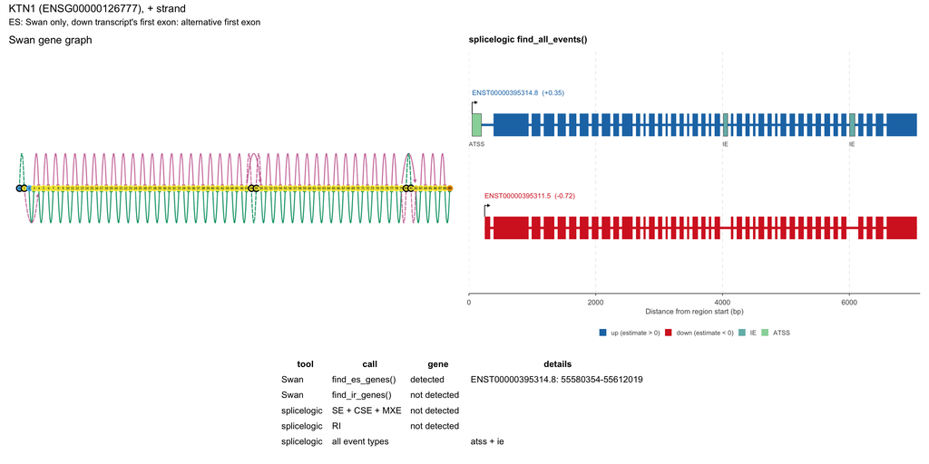

`sg.find_es_genes().query("gid == 'ENSG00000126777'")`

| gid | tid | edge_id |
| --- | --- | --- |
| ENSG00000126777 | ENST00000395314.8 | 12173 |

`sg.find_ir_genes().query("gid == 'ENSG00000126777'")`

**0 rows**: the gene is not in this output

`find_all_events(sl_pre) |> filter(gene_id == "ENSG00000126777.18", event_type %in% c("se", "cse", "mxe"))`

**0 rows**: the gene is not in this output

`find_all_events(sl_pre) |> filter(gene_id == "ENSG00000126777.18", event_type %in% c("ri"))`

**0 rows**: the gene is not in this output

`find_all_events(sl_pre) |> filter(gene_id == "ENSG00000126777.18", event_type %in% c("atss", "ates"))`

| seqnames | start | end | strand | gene_id | tx_id | exon_rank | estimate | event_type | event_tx_id | event_estimate |
| --- | --- | --- | --- | --- | --- | --- | --- | --- | --- | --- |
| chr14 | 55580207 | 55580354 | + | ENSG00000126777.18 | ENST00000395314.8 | 1 | 0.354 | atss | ENST00000395311.5 | -0.724 |

#### TCF12 (ENSG00000140262)

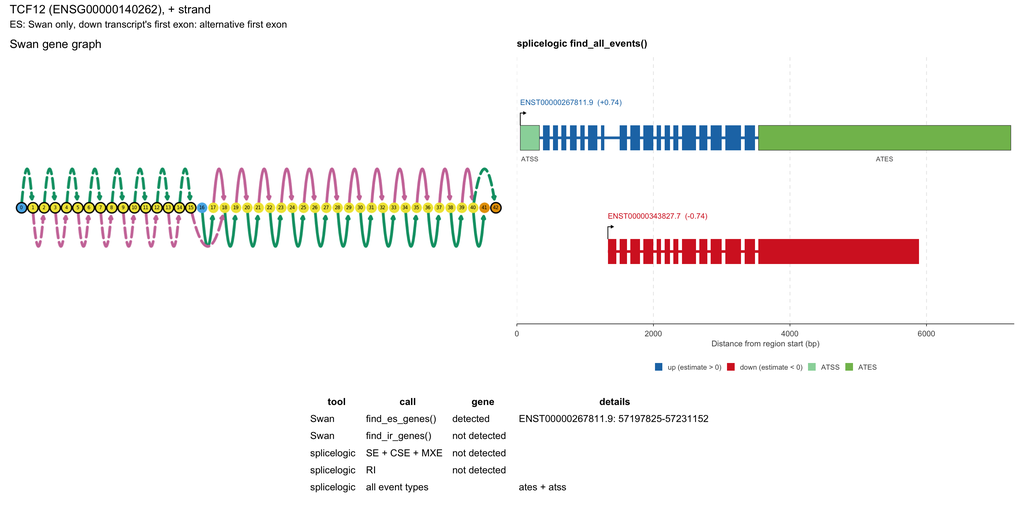

`sg.find_es_genes().query("gid == 'ENSG00000140262'")`

| gid | tid | edge_id |
| --- | --- | --- |
| ENSG00000140262 | ENST00000267811.9 | 11103 |

`sg.find_ir_genes().query("gid == 'ENSG00000140262'")`

**0 rows**: the gene is not in this output

`find_all_events(sl_pre) |> filter(gene_id == "ENSG00000140262.18", event_type %in% c("se", "cse", "mxe"))`

**0 rows**: the gene is not in this output

`find_all_events(sl_pre) |> filter(gene_id == "ENSG00000140262.18", event_type %in% c("ri"))`

**0 rows**: the gene is not in this output

`find_all_events(sl_pre) |> filter(gene_id == "ENSG00000140262.18", event_type %in% c("atss", "ates"))`

| seqnames | start | end | strand | gene_id | tx_id | exon_rank | estimate | event_type | event_tx_id | event_estimate |
| --- | --- | --- | --- | --- | --- | --- | --- | --- | --- | --- |
| chr15 | 56918625 | 56918906 | + | ENSG00000140262.18 | ENST00000267811.9 | 1 | 0.74 | atss | ENST00000343827.7 | -0.74 |
| chr15 | 57286157 | 57289853 | + | ENSG00000140262.18 | ENST00000267811.9 | 20 | 0.74 | ates | ENST00000343827.7 | -0.74 |

#### UGP2 (ENSG00000169764)

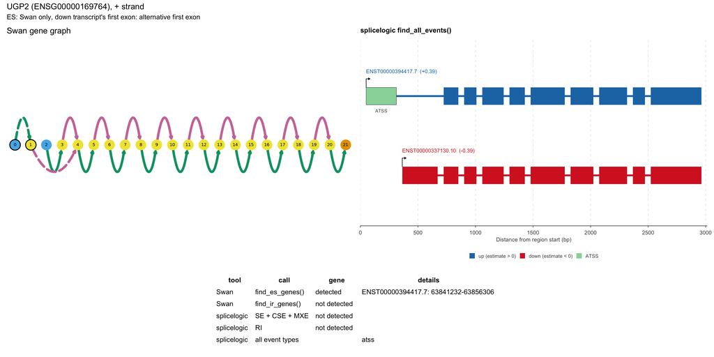

`sg.find_es_genes().query("gid == 'ENSG00000169764'")`

| gid | tid | edge_id |
| --- | --- | --- |
| ENSG00000169764 | ENST00000394417.7 | 12164 |

`sg.find_ir_genes().query("gid == 'ENSG00000169764'")`

**0 rows**: the gene is not in this output

`find_all_events(sl_pre) |> filter(gene_id == "ENSG00000169764.16", event_type %in% c("se", "cse", "mxe"))`

**0 rows**: the gene is not in this output

`find_all_events(sl_pre) |> filter(gene_id == "ENSG00000169764.16", event_type %in% c("ri"))`

**0 rows**: the gene is not in this output

`find_all_events(sl_pre) |> filter(gene_id == "ENSG00000169764.16", event_type %in% c("atss", "ates"))`

| seqnames | start | end | strand | gene_id | tx_id | exon_rank | estimate | event_type | event_tx_id | event_estimate |
| --- | --- | --- | --- | --- | --- | --- | --- | --- | --- | --- |
| chr2 | 63840969 | 63841232 | + | ENSG00000169764.16 | ENST00000394417.7 | 1 | 0.395 | atss | ENST00000337130.10 | -0.395 |

### Plus strand, Swan only: down transcript’s last exon: alternative last exon

#### ANKRD42 (ENSG00000137494)

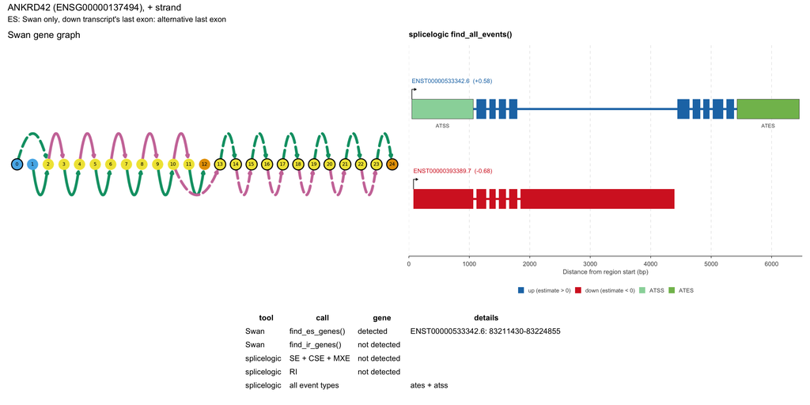

`sg.find_es_genes().query("gid == 'ENSG00000137494'")`

| gid | tid | edge_id |
| --- | --- | --- |
| ENSG00000137494 | ENST00000533342.6 | 12860 |

`sg.find_ir_genes().query("gid == 'ENSG00000137494'")`

**0 rows**: the gene is not in this output

`find_all_events(sl_pre) |> filter(gene_id == "ENSG00000137494.14", event_type %in% c("se", "cse", "mxe"))`

**0 rows**: the gene is not in this output

`find_all_events(sl_pre) |> filter(gene_id == "ENSG00000137494.14", event_type %in% c("ri"))`

**0 rows**: the gene is not in this output

`find_all_events(sl_pre) |> filter(gene_id == "ENSG00000137494.14", event_type %in% c("atss", "ates"))`

| seqnames | start | end | strand | gene_id | tx_id | exon_rank | estimate | event_type | event_tx_id | event_estimate |
| --- | --- | --- | --- | --- | --- | --- | --- | --- | --- | --- |
| chr11 | 83193712 | 83194728 | + | ENSG00000137494.14 | ENST00000533342.6 | 1 | 0.578 | atss | ENST00000393389.7 | -0.678 |
| chr11 | 83247943 | 83248971 | + | ENSG00000137494.14 | ENST00000533342.6 | 11 | 0.578 | ates | ENST00000393389.7 | -0.678 |

#### ANTXR1 (ENSG00000169604)

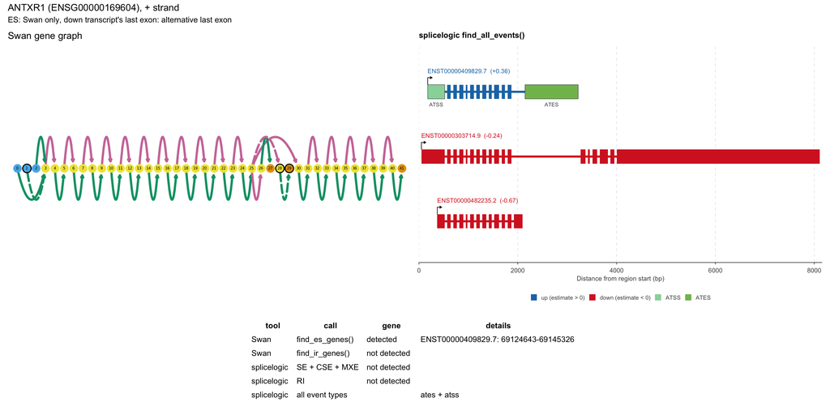

`sg.find_es_genes().query("gid == 'ENSG00000169604'")`

| gid | tid | edge_id |
| --- | --- | --- |
| ENSG00000169604 | ENST00000409829.7 | 12271 |

`sg.find_ir_genes().query("gid == 'ENSG00000169604'")`

**0 rows**: the gene is not in this output

`find_all_events(sl_pre) |> filter(gene_id == "ENSG00000169604.21", event_type %in% c("se", "cse", "mxe"))`

**0 rows**: the gene is not in this output

`find_all_events(sl_pre) |> filter(gene_id == "ENSG00000169604.21", event_type %in% c("ri"))`

**0 rows**: the gene is not in this output

`find_all_events(sl_pre) |> filter(gene_id == "ENSG00000169604.21", event_type %in% c("atss", "ates"))`

| seqnames | start | end | strand | gene_id | tx_id | exon_rank | estimate | event_type | event_tx_id | event_estimate |
| --- | --- | --- | --- | --- | --- | --- | --- | --- | --- | --- |
| chr2 | 69013306 | 69013651 | + | ENSG00000169604.21 | ENST00000409829.7 | 1 | 0.362 | atss | ENST00000303714.9 | -0.237 |
| chr2 | 69013306 | 69013651 | + | ENSG00000169604.21 | ENST00000409829.7 | 1 | 0.362 | atss | ENST00000482235.2 | -0.674 |
| chr2 | 69145326 | 69146401 | + | ENSG00000169604.21 | ENST00000409829.7 | 13 | 0.362 | ates | ENST00000303714.9 | -0.237 |
| chr2 | 69145326 | 69146401 | + | ENSG00000169604.21 | ENST00000409829.7 | 13 | 0.362 | ates | ENST00000482235.2 | -0.674 |

#### BCAP29 (ENSG00000075790)

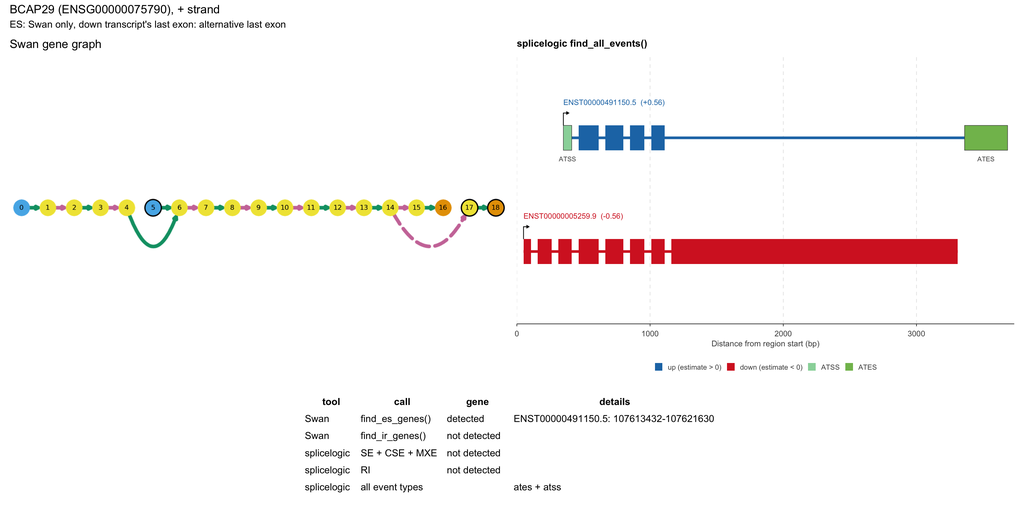

`sg.find_es_genes().query("gid == 'ENSG00000075790'")`

| gid | tid | edge_id |
| --- | --- | --- |
| ENSG00000075790 | ENST00000491150.5 | 12575 |

`sg.find_ir_genes().query("gid == 'ENSG00000075790'")`

**0 rows**: the gene is not in this output

`find_all_events(sl_pre) |> filter(gene_id == "ENSG00000075790.12", event_type %in% c("se", "cse", "mxe"))`

**0 rows**: the gene is not in this output

`find_all_events(sl_pre) |> filter(gene_id == "ENSG00000075790.12", event_type %in% c("ri"))`

**0 rows**: the gene is not in this output

`find_all_events(sl_pre) |> filter(gene_id == "ENSG00000075790.12", event_type %in% c("atss", "ates"))`

| seqnames | start | end | strand | gene_id | tx_id | exon_rank | estimate | event_type | event_tx_id | event_estimate |
| --- | --- | --- | --- | --- | --- | --- | --- | --- | --- | --- |
| chr7 | 107583919 | 107583982 | + | ENSG00000075790.12 | ENST00000491150.5 | 1 | 0.561 | atss | ENST00000005259.9 | -0.561 |
| chr7 | 107621630 | 107621953 | + | ENSG00000075790.12 | ENST00000491150.5 | 6 | 0.561 | ates | ENST00000005259.9 | -0.561 |

#### BCCIP (ENSG00000107949)

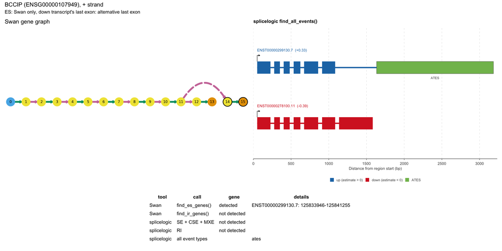

`sg.find_es_genes().query("gid == 'ENSG00000107949'")`

| gid | tid | edge_id |
| --- | --- | --- |
| ENSG00000107949 | ENST00000299130.7 | 11224 |

`sg.find_ir_genes().query("gid == 'ENSG00000107949'")`

**0 rows**: the gene is not in this output

`find_all_events(sl_pre) |> filter(gene_id == "ENSG00000107949.17", event_type %in% c("se", "cse", "mxe"))`

**0 rows**: the gene is not in this output

`find_all_events(sl_pre) |> filter(gene_id == "ENSG00000107949.17", event_type %in% c("ri"))`

**0 rows**: the gene is not in this output

`find_all_events(sl_pre) |> filter(gene_id == "ENSG00000107949.17", event_type %in% c("atss", "ates"))`

| seqnames | start | end | strand | gene_id | tx_id | exon_rank | estimate | event_type | event_tx_id | event_estimate |
| --- | --- | --- | --- | --- | --- | --- | --- | --- | --- | --- |
| chr10 | 125841255 | 125842805 | + | ENSG00000107949.17 | ENST00000299130.7 | 7 | 0.332 | ates | ENST00000278100.11 | -0.39 |

#### CDC42 (ENSG00000070831)

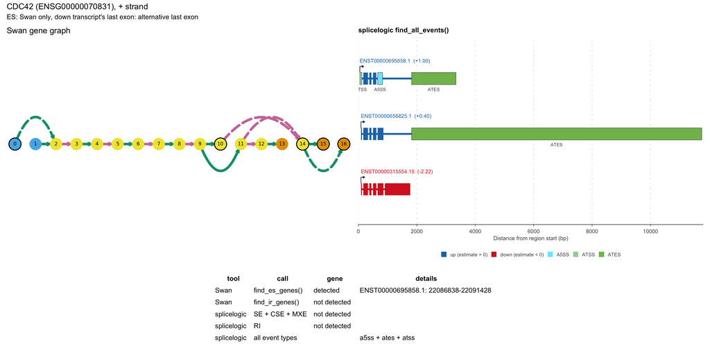

`sg.find_es_genes().query("gid == 'ENSG00000070831'")`

| gid | tid | edge_id |
| --- | --- | --- |
| ENSG00000070831 | ENST00000695858.1 | 13421 |

`sg.find_ir_genes().query("gid == 'ENSG00000070831'")`

**0 rows**: the gene is not in this output

`find_all_events(sl_pre) |> filter(gene_id == "ENSG00000070831.18", event_type %in% c("se", "cse", "mxe"))`

**0 rows**: the gene is not in this output

`find_all_events(sl_pre) |> filter(gene_id == "ENSG00000070831.18", event_type %in% c("ri"))`

**0 rows**: the gene is not in this output

`find_all_events(sl_pre) |> filter(gene_id == "ENSG00000070831.18", event_type %in% c("atss", "ates"))`

| seqnames | start | end | strand | gene_id | tx_id | exon_rank | estimate | event_type | event_tx_id | event_estimate |
| --- | --- | --- | --- | --- | --- | --- | --- | --- | --- | --- |
| chr1 | 22052671 | 22052742 | + | ENSG00000070831.18 | ENST00000695858.1 | 1 | 0.998 | atss | ENST00000315554.15 | -2.219 |
| chr1 | 22091428 | 22092946 | + | ENSG00000070831.18 | ENST00000695858.1 | 6 | 0.998 | ates | ENST00000315554.15 | -2.219 |
| chr1 | 22091428 | 22101360 | + | ENSG00000070831.18 | ENST00000656825.1 | 6 | 0.399 | ates | ENST00000315554.15 | -2.219 |

#### CNOT9 (ENSG00000144580)

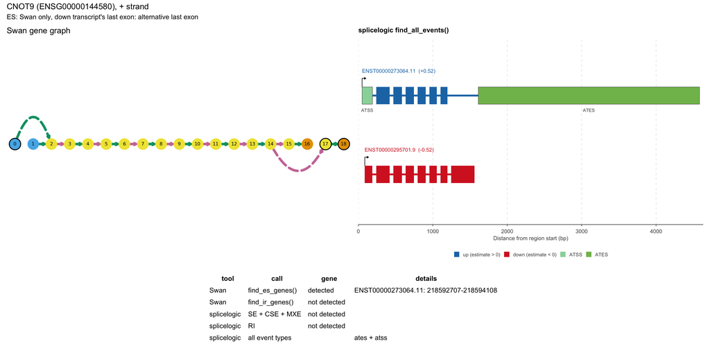

`sg.find_es_genes().query("gid == 'ENSG00000144580'")`

| gid | tid | edge_id |
| --- | --- | --- |
| ENSG00000144580 | ENST00000273064.11 | 11153 |

`sg.find_ir_genes().query("gid == 'ENSG00000144580'")`

**0 rows**: the gene is not in this output

`find_all_events(sl_pre) |> filter(gene_id == "ENSG00000144580.15", event_type %in% c("se", "cse", "mxe"))`

**0 rows**: the gene is not in this output

`find_all_events(sl_pre) |> filter(gene_id == "ENSG00000144580.15", event_type %in% c("ri"))`

**0 rows**: the gene is not in this output

`find_all_events(sl_pre) |> filter(gene_id == "ENSG00000144580.15", event_type %in% c("atss", "ates"))`

| seqnames | start | end | strand | gene_id | tx_id | exon_rank | estimate | event_type | event_tx_id | event_estimate |
| --- | --- | --- | --- | --- | --- | --- | --- | --- | --- | --- |
| chr2 | 218568839 | 218568978 | + | ENSG00000144580.15 | ENST00000273064.11 | 1 | 0.517 | atss | ENST00000295701.9 | -0.517 |
| chr2 | 218594108 | 218597080 | + | ENSG00000144580.15 | ENST00000273064.11 | 8 | 0.517 | ates | ENST00000295701.9 | -0.517 |

#### LRCH3 (ENSG00000186001)

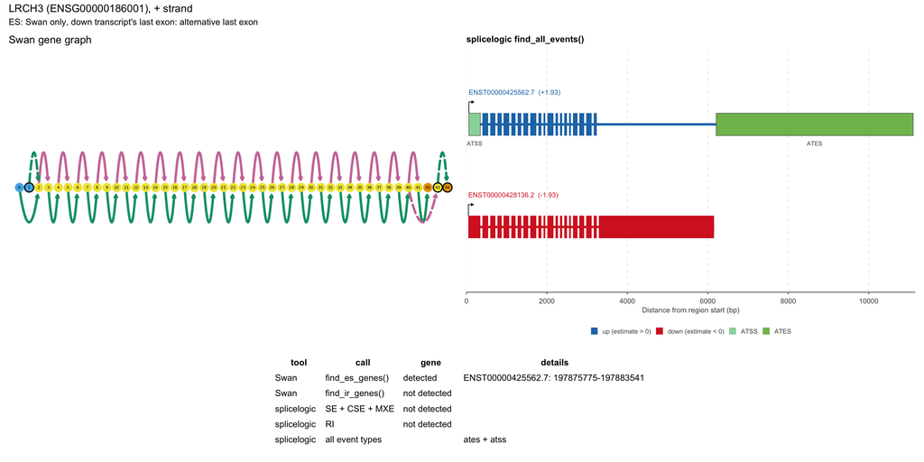

`sg.find_es_genes().query("gid == 'ENSG00000186001'")`

| gid | tid | edge_id |
| --- | --- | --- |
| ENSG00000186001 | ENST00000425562.7 | 12334 |

`sg.find_ir_genes().query("gid == 'ENSG00000186001'")`

**0 rows**: the gene is not in this output

`find_all_events(sl_pre) |> filter(gene_id == "ENSG00000186001.14", event_type %in% c("se", "cse", "mxe"))`

**0 rows**: the gene is not in this output

`find_all_events(sl_pre) |> filter(gene_id == "ENSG00000186001.14", event_type %in% c("ri"))`

**0 rows**: the gene is not in this output

`find_all_events(sl_pre) |> filter(gene_id == "ENSG00000186001.14", event_type %in% c("atss", "ates"))`

| seqnames | start | end | strand | gene_id | tx_id | exon_rank | estimate | event_type | event_tx_id | event_estimate |
| --- | --- | --- | --- | --- | --- | --- | --- | --- | --- | --- |
| chr3 | 197791254 | 197791540 | + | ENSG00000186001.14 | ENST00000425562.7 | 1 | 1.928 | atss | ENST00000428136.2 | -1.928 |
| chr3 | 197883541 | 197888436 | + | ENSG00000186001.14 | ENST00000425562.7 | 21 | 1.928 | ates | ENST00000428136.2 | -1.928 |

#### MAP3K20 (ENSG00000091436)

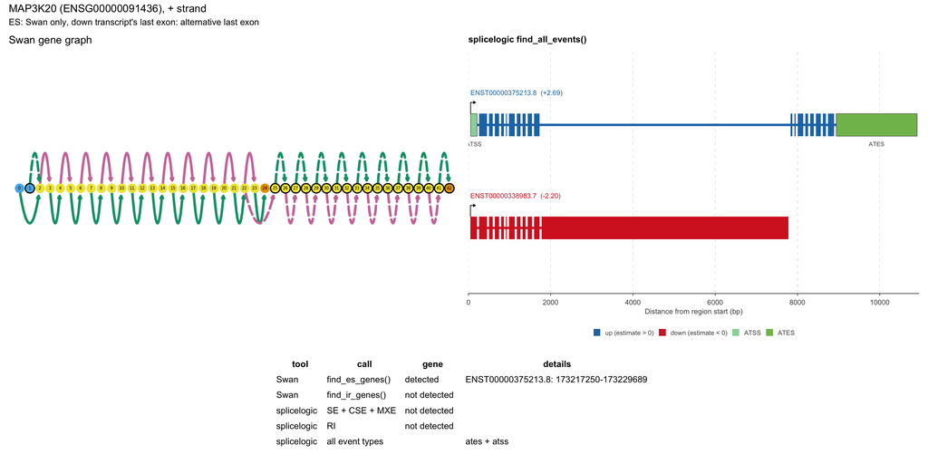

`sg.find_es_genes().query("gid == 'ENSG00000091436'")`

| gid | tid | edge_id |
| --- | --- | --- |
| ENSG00000091436 | ENST00000375213.8 | 11926 |

`sg.find_ir_genes().query("gid == 'ENSG00000091436'")`

**0 rows**: the gene is not in this output

`find_all_events(sl_pre) |> filter(gene_id == "ENSG00000091436.17", event_type %in% c("se", "cse", "mxe"))`

**0 rows**: the gene is not in this output

`find_all_events(sl_pre) |> filter(gene_id == "ENSG00000091436.17", event_type %in% c("ri"))`

**0 rows**: the gene is not in this output

`find_all_events(sl_pre) |> filter(gene_id == "ENSG00000091436.17", event_type %in% c("atss", "ates"))`

| seqnames | start | end | strand | gene_id | tx_id | exon_rank | estimate | event_type | event_tx_id | event_estimate |
| --- | --- | --- | --- | --- | --- | --- | --- | --- | --- | --- |
| chr2 | 173075846 | 173076002 | + | ENSG00000091436.17 | ENST00000375213.8 | 1 | 2.69 | atss | ENST00000338983.7 | -2.201 |
| chr2 | 173266050 | 173268015 | + | ENSG00000091436.17 | ENST00000375213.8 | 20 | 2.69 | ates | ENST00000338983.7 | -2.201 |

#### MYL6 (ENSG00000092841)

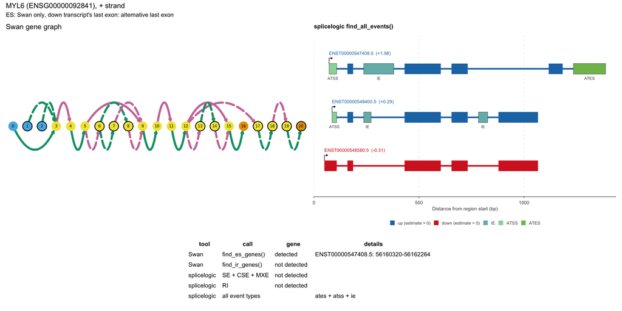

`sg.find_es_genes().query("gid == 'ENSG00000092841'")`

| gid | tid | edge_id |
| --- | --- | --- |
| ENSG00000092841 | ENST00000547408.5 | 12903 |
| ENSG00000092841 | ENST00000547408.5 | 12903 |

`sg.find_ir_genes().query("gid == 'ENSG00000092841'")`

**0 rows**: the gene is not in this output

`find_all_events(sl_pre) |> filter(gene_id == "ENSG00000092841.19", event_type %in% c("se", "cse", "mxe"))`

**0 rows**: the gene is not in this output

`find_all_events(sl_pre) |> filter(gene_id == "ENSG00000092841.19", event_type %in% c("ri"))`

**0 rows**: the gene is not in this output

`find_all_events(sl_pre) |> filter(gene_id == "ENSG00000092841.19", event_type %in% c("atss", "ates"))`

| seqnames | start | end | strand | gene_id | tx_id | exon_rank | estimate | event_type | event_tx_id | event_estimate |
| --- | --- | --- | --- | --- | --- | --- | --- | --- | --- | --- |
| chr12 | 56158368 | 56158404 | + | ENSG00000092841.19 | ENST00000547408.5 | 1 | 1.984 | atss | ENST00000548580.5 | -0.31 |
| chr12 | 56158382 | 56158404 | + | ENSG00000092841.19 | ENST00000548400.5 | 1 | 0.285 | atss | ENST00000548580.5 | -0.31 |
| chr12 | 56162855 | 56163008 | + | ENSG00000092841.19 | ENST00000547408.5 | 7 | 1.984 | ates | ENST00000548580.5 | -0.31 |